# **Data Cleaning**

# **Time Series Plot and Interpretations**

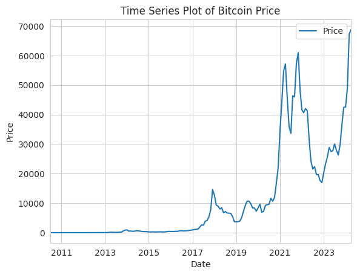

```python
monthly_data.plot(y='Price', title='Time Series Plot of Bitcoin Price')
plt.xlabel('Date')
plt.ylabel('Price')
plt.show()
```

Series is not stationary in mean. Although some up and down in the prices, it can be said that there is an increasing trend. Also, it seems that there is no seasonality.

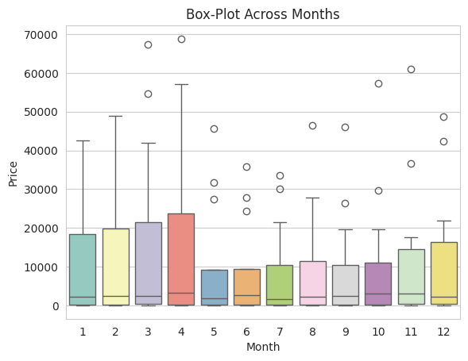

```python
monthly_data['Month'] = [monthly_data.index[i].month for i in range(len(monthly_data))]
sns.boxplot( y=monthly_data["Price"], x=monthly_data['Month'],palette = "Set3" );
plt.title('Box-Plot Across Months')
plt.xlabel( "Month" )
plt.ylabel( "Price")
plt.show()
```

The median values for each month are close to each other and in the same range. Therefore, it can be said that there is no seasonality. Also we have outliers in the dataset in monthly basis.

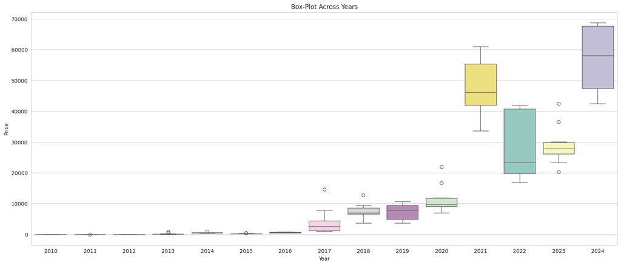

```python
monthly_data['Year'] = [monthly_data.index[i].year for i in range(len(monthly_data))]
plt.figure(figsize=(20, 8))
sns.boxplot( y=monthly_data["Price"], x=monthly_data['Year'],palette = "Set3" );
plt.title('Box-Plot Across Years')
plt.xlabel( "Year" )
plt.ylabel( "Price")
plt.show()
```

Similar to the interpretations of autoplot, there exists up and down in the prices. If we compare the beginning and final, it can be said that there is an increasing trend. Also we have outliers in the dataset in yearly basis.

```python
monthly_data.tail(10)
```

| Date | Price | Open | High | Low | Volume | Change | Month | Year |
| --- | --- | --- | --- | --- | --- | --- | --- | --- |
| 2023-07-31 | 30056.380645 | 30472.9 | 31764.5 | 28890.7 | 39959.032258 | -0.001265 | 7 | 2023 |
| 2023-08-31 | 27866.067742 | 29232.3 | 30168.6 | 25481.9 | 44097.096774 | -0.003642 | 8 | 2023 |
| 2023-09-30 | 26307.326667 | 25938.3 | 27480.7 | 24923.1 | 37637.333333 | 0.001350 | 9 | 2023 |
| 2023-10-31 | 29748.264516 | 26962.5 | 35191.4 | 26558.4 | 51811.612903 | 0.008377 | 10 | 2023 |
| 2023-11-30 | 36587.746667 | 34648.3 | 38400.8 | 34124.2 | 48870.000000 | 0.003063 | 11 | 2023 |
| 2023-12-31 | 42448.675862 | 37712.9 | 44697.6 | 37618.3 | 50498.965517 | 0.002755 | 12 | 2023 |
| 2024-01-31 | 42528.144000 | 42272.5 | 46503.2 | 38546.9 | 57661.200000 | 0.001524 | 1 | 2024 |
| 2024-02-29 | 48963.920833 | 42580.1 | 63653.4 | 41890.5 | 55837.500000 | 0.009012 | 2 | 2024 |
| 2024-03-31 | 67299.050000 | 61157.3 | 72398.1 | 60790.9 | 76821.666667 | 0.011783 | 3 | 2024 |
| 2024-04-30 | 68793.342857 | 71329.3 | 71442.1 | 64559.0 | 73622.857143 | 0.009200 | 4 | 2024 |

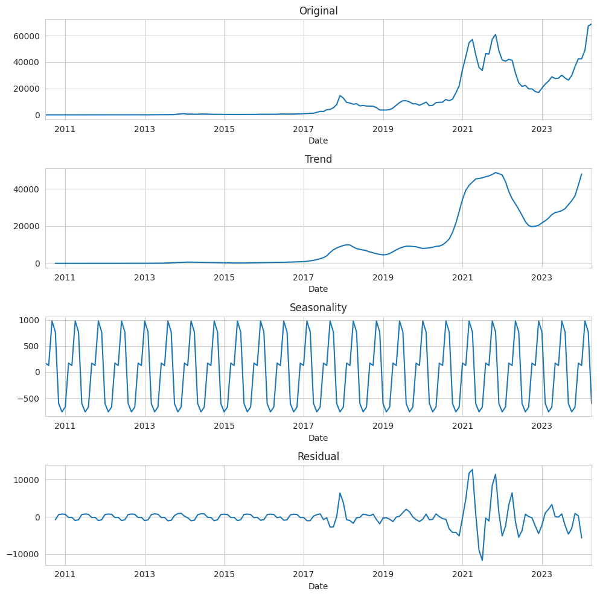

```python
import pandas as pd
import matplotlib.pyplot as plt
import statsmodels.api as sm

# Assuming monthly_data is your DataFrame with Date as index and Price as a column
# Replace monthly_data with your actual DataFrame

# Perform seasonal decomposition
decomposition = sm.tsa.seasonal_decompose(monthly_data['Price'], model='additive', period=7)  # Assuming monthly seasonality

# Plotting the components
fig, axes = plt.subplots(4, 1, figsize=(10, 10))
monthly_data['Price'].plot(title='Original', ax=axes[0])
decomposition.trend.plot(title='Trend', ax=axes[1])
decomposition.seasonal.plot(title='Seasonality', ax=axes[2])
decomposition.resid.plot(title='Residual', ax=axes[3])
plt.tight_layout()
plt.show()
```

From trend plot, we can say that we have a positive trend even if there exists some breaks. Also, we can see there is no stationarity.

> **Cross Validation**

```python
# Split the dataset as train and test.
training_data = monthly_data[monthly_data.index < '2023-05-01']
print(training_data.shape)

testing_data = monthly_data[monthly_data.index >= '2023-05-01']
print(testing_data.shape)
```

```
(154, 8)
(12, 8)
```

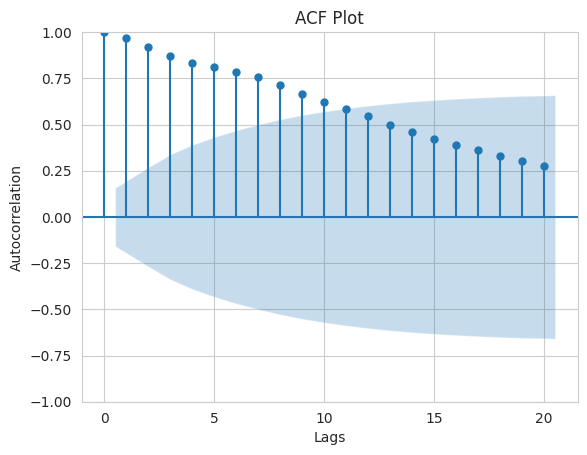

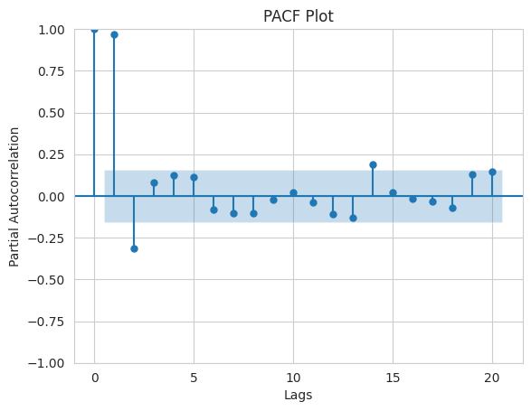

```python
from statsmodels.graphics.tsaplots import plot_acf, plot_pacf
# Plot ACF
plot_acf(training_data['Price'], lags=20)
plt.title('ACF Plot')
plt.xlabel('Lags')
plt.ylabel('Autocorrelation')
plt.show()

# Plot PACF
plot_pacf(training_data['Price'], lags=20)
plt.title('PACF Plot')
plt.xlabel('Lags')
plt.ylabel('Partial Autocorrelation')
plt.show()
```

There is slow linear decay in ACF plot which indicates that the series is not stationary. Now, check the related tests.

```python
training_data['Price'].mean()
```

```
8958.984061045336
```

It is not close to 0.

```python
from statsmodels.tsa.stattools import kpss, adfuller
!pip install arch
from arch.unitroot import PhillipsPerron
```

```
     ━━━━━━━━━━━━━━━━━━━━━━━━━━━━━━━━━━━━━━━━ 983.4/983.4 kB 9.6 MB/s eta 0:00:00
```

- *KPSS level test: H0 suggests the process is stationary.*

```python
kpsstest_level = kpss(training_data['Price'], regression='c', nlags="auto")
kpss_output = pd.Series(kpsstest_level[0:3], index=['Test Statistic','p-value','#Lags Used'])
print(kpss_output)
```

```
Test Statistic    1.108801
p-value           0.010000
#Lags Used        8.000000
dtype: float64
```

Since the p-value is smaller than 0.05, we reject H0. KPSS test suggest that the Process is not stationary.

- *KPSS trend test: H0 suggests there is no stochastic process.*

```python
kpsstest_trend = kpss(training_data['Price'], regression='ct', nlags="auto")
kpss_output = pd.Series(kpsstest_trend[0:3], index=['Test Statistic','p-value','#Lags Used'])
print(kpss_output)
```

```
Test Statistic    0.216448
p-value           0.010000
#Lags Used        8.000000
dtype: float64
```

By p-value, reject H0. There exists stochastic process. We need to use differencing.

- *PP test: H0 suggests that process is not stationary and have unit root.*

```python
pp = PhillipsPerron(training_data['Price'],lags=20)
print(pp.summary().as_text())
```

```
     Phillips-Perron Test (Z-tau)
=====================================
Test Statistic                 -1.196
P-value                         0.675
Lags                               20
-------------------------------------

Trend: Constant
Critical Values: -3.47 (1%), -2.88 (5%), -2.58 (10%)
Null Hypothesis: The process contains a unit root.
Alternative Hypothesis: The process is weakly stationary.
```

Fail to Reject H0. PP test suggests that process is not stationary and has unit root.

- *ADF test: H0 suggests the series is not stationary.*

```python
adf_result = adfuller(training_data['Price'])
print("ADF Test:")
print("ADF Statistic:", adf_result[0])
print("p-value:", adf_result[1])
```

```
ADF Test:
ADF Statistic: -1.5029744034083437
p-value: 0.532039434266455
```

By p-value, we fail to reject null hypothesis. The series is not stationary.

```python
# Number of differences for stationarity
!pip install pmdarima
from pmdarima.arima.utils import ndiffs
print(ndiffs(training_data['Price'], test='adf'))
print(ndiffs(training_data['Price'], test='kpss'))
print(ndiffs(training_data['Price'], test='pp'))
```

```
     ━━━━━━━━━━━━━━━━━━━━━━━━━━━━━━━━━━━━━━━━ 2.1/2.1 MB 18.7 MB/s eta 0:00:00
1
1
1
```

All the tests suggest that We should take one regular difference.

[output not shown]

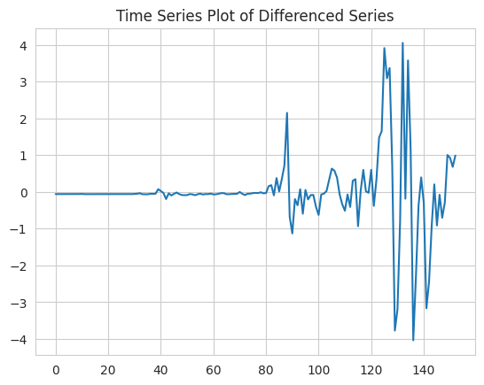

```python
import numpy as np
import matplotlib.pyplot as plt
from sklearn.preprocessing import StandardScaler

dif_train = np.diff(training_data['Price'])

scaler = StandardScaler()

# Fit and transform the data
scaled_dif_train = scaler.fit_transform(dif_train.reshape(-1, 1))

# Display the scaled data
print(scaled_dif_train.flatten())


plt.plot(scaled_dif_train)
plt.title('Time Series Plot of Differenced Series')
plt.show()
```

The plot shows that series is stationary around zero. Now, look at the plot and tests.

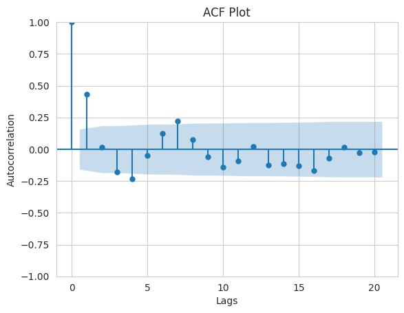

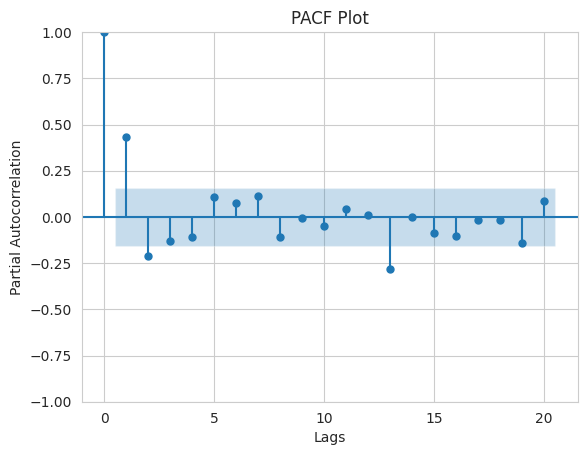

```python
# Plot ACF
plot_acf(dif_train, lags=20)
plt.title('ACF Plot')
plt.xlabel('Lags')
plt.ylabel('Autocorrelation')
plt.show()

# Plot PACF
plot_pacf(dif_train, lags=20)
plt.title('PACF Plot')
plt.xlabel('Lags')
plt.ylabel('Partial Autocorrelation')
plt.show()
```

```python
dif_train.mean()
```

```
188.51222222222222
```

```python
pp = PhillipsPerron(dif_train,lags=20)
print(pp.summary().as_text())
```

```
     Phillips-Perron Test (Z-tau)
=====================================
Test Statistic                 -6.844
P-value                         0.000
Lags                               20
-------------------------------------

Trend: Constant
Critical Values: -3.47 (1%), -2.88 (5%), -2.58 (10%)
Null Hypothesis: The process contains a unit root.
Alternative Hypothesis: The process is weakly stationary.
```

Reject H0. PP test suggests that process is stationary and does not have unit root.

```python
adf_result = adfuller(dif_train)
print("ADF Test:")
print("ADF Statistic:", adf_result[0])
print("p-value:", adf_result[1])
```

```
ADF Test:
ADF Statistic: -4.048593458148034
p-value: 0.0011763814043723492
```

By p-value, we reject null hypothesis. The series is stationary.

```python
df_scaled_dif_train = pd.DataFrame(scaled_dif_train, columns=['Price'], index=training_data.index[1:])
df_scaled_dif_train.head()
```

| Date | Price |
| --- | --- |
| 2010-08-31 | -0.060703 |
| 2010-09-30 | -0.060703 |
| 2010-10-31 | -0.060696 |
| 2010-11-30 | -0.060656 |
| 2010-12-31 | -0.060711 |

> **Model Suggestions and Model Comparison**

> > *ARIMA(1,1,2)*

```
Training data shape: (154, 8)
Testing data shape: (12, 8)
```

```
Evaluation Metrics for Training Data:
**Root Mean Squared Error (RMSE):** 2748.94218229669
**Mean Absolute Percentage Error (MAPE):** 18.715780122922286
**Mean Absolute Scaled Error (MASE):** 0.8773683465651465

Evaluation Metrics for Testing Data:
**Root Mean Squared Error (RMSE):** 17109.900816323254
**Mean Absolute Percentage Error (MAPE):** 22.5595221503507
**Mean Absolute Scaled Error (MASE):** 8.346019187625716
```

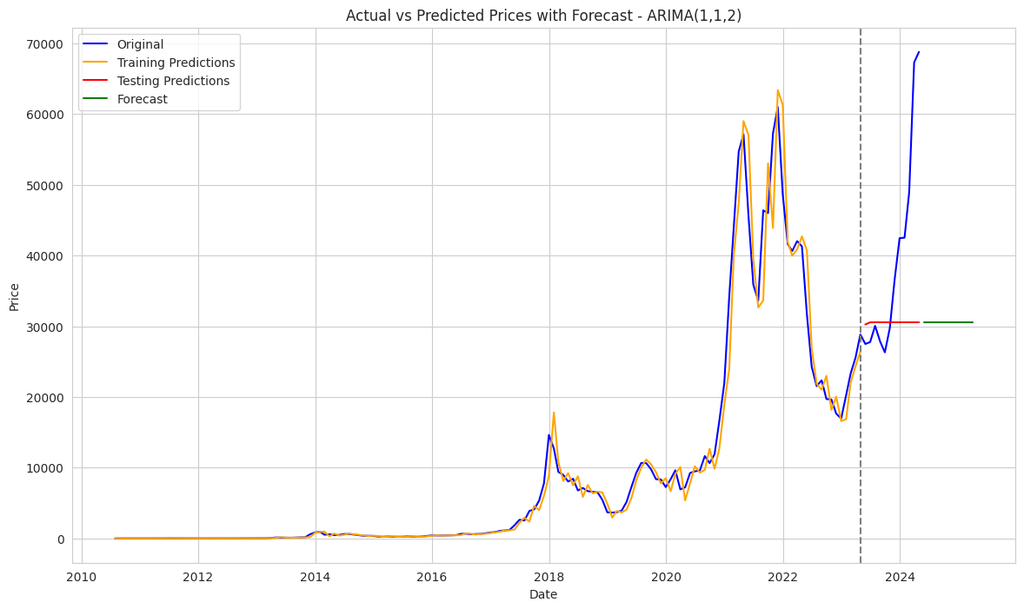

```python
monthly_data2 = monthly_data.copy()
import pandas as pd
import numpy as np
from statsmodels.tsa.arima.model import ARIMA
from sklearn.metrics import mean_squared_error, mean_absolute_error
import matplotlib.pyplot as plt

# Assuming monthly_data2 is already defined and available

# Split the dataset into training and testing sets
training_data = monthly_data2[monthly_data2.index < pd.to_datetime('2023-05-01')]
print("Training data shape:", training_data.shape)

testing_data = monthly_data2[monthly_data2.index >= pd.to_datetime('2023-05-01')]
print("Testing data shape:", testing_data.shape)

# Separate target variable (Price) for ARIMA model
y_train = training_data['Price']
y_test = testing_data['Price']

# Fit ARIMA model with parameters (4,1,2)
arima_order = (1, 1, 2)
arima_model = ARIMA(y_train, order=arima_order)
arima_fitted = arima_model.fit()

# Make predictions on the training data
train_predictions = arima_fitted.predict(start=0, end=len(y_train)-1, typ='levels')

# Make predictions on the testing data
test_start = len(y_train)
test_end = test_start + len(y_test) - 1
test_predictions = arima_fitted.predict(start=test_start, end=test_end, typ='levels')

# Calculate evaluation metrics for training data
train_mse = mean_squared_error(y_train, train_predictions)
train_rmse = np.sqrt(train_mse)
train_mape = np.mean(np.abs((y_train - train_predictions) / y_train)) * 100

# Calculate evaluation metrics for testing data
test_mse = mean_squared_error(y_test, test_predictions)
test_rmse = np.sqrt(test_mse)
test_mape = np.mean(np.abs((y_test - test_predictions) / y_test)) * 100

# MASE calculation
# Calculate in-sample one-step naive forecast error
naive_forecast_train = training_data['Price'].shift(1)
naive_forecast_error_train = np.abs(training_data['Price'][1:] - naive_forecast_train[1:])
naive_mae_train = np.mean(naive_forecast_error_train)

# Calculate MASE for training data
train_mase = mean_absolute_error(y_train, train_predictions) / naive_mae_train

# Calculate in-sample one-step naive forecast error for testing data
naive_forecast_test = testing_data['Price'].shift(1)
naive_forecast_error_test = np.abs(testing_data['Price'][1:] - naive_forecast_test[1:])
naive_mae_test = np.mean(naive_forecast_error_test)

# Calculate MASE for testing data
test_mase = mean_absolute_error(y_test, test_predictions) / naive_mae_train

print("Evaluation Metrics for Training Data:")
print(f"**Root Mean Squared Error (RMSE):** {train_rmse}")
print(f"**Mean Absolute Percentage Error (MAPE):** {train_mape}")
print(f"**Mean Absolute Scaled Error (MASE):** {train_mase}")

print("\nEvaluation Metrics for Testing Data:")
print(f"**Root Mean Squared Error (RMSE):** {test_rmse}")
print(f"**Mean Absolute Percentage Error (MAPE):** {test_mape}")
print(f"**Mean Absolute Scaled Error (MASE):** {test_mase}")

# Extend the date index for forecast
forecast_dates = pd.date_range(start=testing_data.index[-1], periods=12, freq='M')[1:]

# Make predictions for the forecast period
forecast_start = test_end + 1
forecast_end = forecast_start + len(forecast_dates) - 1
forecast_predictions = arima_fitted.predict(start=forecast_start, end=forecast_end, typ='levels')

# Plot actual vs predicted prices including forecast
plt.figure(figsize=(14, 8))

# Plot the original prices
plt.plot(monthly_data2.index, monthly_data2['Price'], label='Original', color='blue')

# Plot the training predictions
plt.plot(training_data.index, train_predictions, label='Training Predictions', color='orange')

# Plot the testing predictions
plt.plot(testing_data.index, test_predictions, label='Testing Predictions', color='red')

# Add a vertical line to separate training and testing data
plt.axvline(x=pd.to_datetime('2023-05-01'), color='gray', linestyle='--')

# Plot the forecast
plt.plot(forecast_dates, forecast_predictions, label='Forecast', color='green')

plt.xlabel('Date')
plt.ylabel('Price')
plt.title('Actual vs Predicted Prices with Forecast - ARIMA(1,1,2)')
plt.legend()
plt.show()
```

```python
import pandas as pd
import numpy as np
from statsmodels.tsa.arima.model import ARIMA
from sklearn.metrics import mean_squared_error, mean_absolute_error
import matplotlib.pyplot as plt

# Assuming monthly_data2 is already defined and available

# Split the dataset into training and testing sets
training_data = monthly_data2[monthly_data2.index < pd.to_datetime('2023-05-01')]
print("Training data shape:", training_data.shape)

testing_data = monthly_data2[monthly_data2.index >= pd.to_datetime('2023-05-01')]
print("Testing data shape:", testing_data.shape)

# Separate target variable (Price) for ARIMA model
y_train = training_data['Price']
y_test = testing_data['Price']

# Fit ARIMA model with parameters (4,1,2)
arima_order = (4, 1, 2)
arima_model = ARIMA(y_train, order=arima_order)
arima_fitted = arima_model.fit()

# Make predictions on the training data
train_predictions = arima_fitted.predict(start=0, end=len(y_train)-1, typ='levels')

# Make predictions on the testing data
test_start = len(y_train)
test_end = test_start + len(y_test) - 1
test_predictions = arima_fitted.predict(start=test_start, end=test_end, typ='levels')

# Calculate evaluation metrics for training data
train_mse = mean_squared_error(y_train, train_predictions)
train_rmse = np.sqrt(train_mse)
train_mape = np.mean(np.abs((y_train - train_predictions) / y_train)) * 100

# Calculate evaluation metrics for testing data
test_mse = mean_squared_error(y_test, test_predictions)
test_rmse = np.sqrt(test_mse)
test_mape = np.mean(np.abs((y_test - test_predictions) / y_test)) * 100

# MASE calculation
# Calculate in-sample one-step naive forecast error
naive_forecast_train = training_data['Price'].shift(1)
naive_forecast_error_train = np.abs(training_data['Price'][1:] - naive_forecast_train[1:])
naive_mae_train = np.mean(naive_forecast_error_train)

# Calculate MASE for training data
train_mase = mean_absolute_error(y_train, train_predictions) / naive_mae_train

# Calculate in-sample one-step naive forecast error for testing data
naive_forecast_test = testing_data['Price'].shift(1)
naive_forecast_error_test = np.abs(testing_data['Price'][1:] - naive_forecast_test[1:])
naive_mae_test = np.mean(naive_forecast_error_test)

# Calculate MASE for testing data
test_mase = mean_absolute_error(y_test, test_predictions) / naive_mae_train

print("Evaluation Metrics for Training Data:")
print(f"**Root Mean Squared Error (RMSE):** {train_rmse}")
print(f"**Mean Absolute Percentage Error (MAPE):** {train_mape}")
print(f"**Mean Absolute Scaled Error (MASE):** {train_mase}")

print("\nEvaluation Metrics for Testing Data:")
print(f"**Root Mean Squared Error (RMSE):** {test_rmse}")
print(f"**Mean Absolute Percentage Error (MAPE):** {test_mape}")
print(f"**Mean Absolute Scaled Error (MASE):** {test_mase}")

# Extend the date index for forecast
forecast_dates = pd.date_range(start=testing_data.index[-1], periods=12, freq='M')[1:]

# Make predictions for the forecast period
forecast_start = test_end + 1
forecast_end = forecast_start + len(forecast_dates) - 1
forecast_predictions = arima_fitted.predict(start=forecast_start, end=forecast_end, typ='levels')

# Plot actual vs predicted prices including forecast
plt.figure(figsize=(14, 8))

# Plot the original prices
plt.plot(monthly_data2.index, monthly_data2['Price'], label='Original', color='blue')

# Plot the training predictions
plt.plot(training_data.index, train_predictions, label='Training Predictions', color='orange')

# Plot the testing predictions
plt.plot(testing_data.index, test_predictions, label='Testing Predictions', color='red')

# Add a vertical line to separate training and testing data
plt.axvline(x=pd.to_datetime('2023-05-01'), color='gray', linestyle='--')

# Plot the forecast
plt.plot(forecast_dates, forecast_predictions, label='Forecast', color='green')

plt.xlabel('Date')
plt.ylabel('Price')
plt.title('Actual vs Predicted Prices with Forecast - ARIMA(4,1,2)')
plt.legend()
plt.show()
```

[output not shown]

# **Diagnostic Checking**

After estimating the model, the goodness of fit of the model and some assumptions should be checked.

The following assumptions should be satisfied

- Errors must be Normal distribution with 0 mean.
- Errors must be independent from each other (i.e WN).
- Error variance must be constant (Homoscedastic)

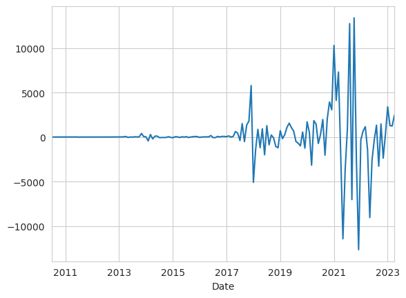

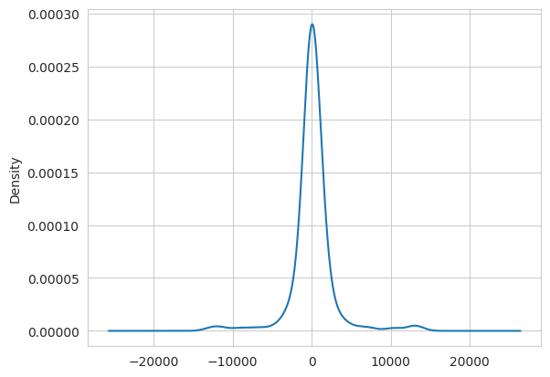

```
count      154.000000
mean       121.311511
std       2755.224227
min     -12658.135039
25%        -53.393596
50%          2.153344
75%        340.096043
max      13388.434528
dtype: float64
```

```python
residuals = arima_fitted.resid
residuals.plot()
plt.show()
residuals.plot(kind='kde')
plt.show()
print(residuals.describe())
```

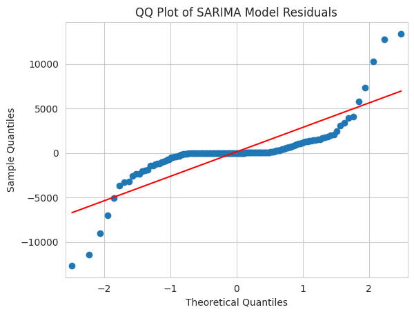

```python
# PQQ plot
sm.qqplot(residuals, line='s') # s or 45?
plt.title('QQ Plot of SARIMA Model Residuals')
plt.show()
```

```python
# Tukey's five-number summary
min_res = np.min(residuals)
q1_res = np.percentile(residuals, 25)
median_res = np.median(residuals)
q3_res = np.percentile(residuals, 75)
max_res = np.max(residuals)

print("Tukey's Five-Number Summary for Residuals:")
print(f"Minimum: {min_res:.2f}")
print(f"Q1: {q1_res:.2f}")
print(f"Median: {median_res:.2f}")
print(f"Q3: {q3_res:.2f}")
print(f"Maximum: {max_res:.2f}")
```

```
Tukey's Five-Number Summary for Residuals:
Minimum: -12658.14
Q1: -53.39
Median: 2.15
Q3: 340.10
Maximum: 13388.43
```

```python
from scipy.stats import jarque_bera, shapiro
# Perform Jarque-Bera test
jb_stat, jb_p_value = jarque_bera(residuals)
print("\nJarque-Bera Test:")
print(f"Statistic: {jb_stat:.2f}")
print(f"P-value: {jb_p_value:.2f}")

# Perform Shapiro-Wilk test
sw_stat, sw_p_value = shapiro(residuals)
print("\nShapiro-Wilk Test:")
print(f"Statistic: {sw_stat:.2f}")
print(f"P-value: {sw_p_value:.2f}")
```

```
Jarque-Bera Test:
Statistic: 853.12
P-value: 0.00

Shapiro-Wilk Test:
Statistic: 0.65
P-value: 0.00
```

```python
# Detection of serial autocorrelation
# Breusch-Godfrey test
import statsmodels.stats.diagnostic as smd
bg_test = smd.acorr_breusch_godfrey(arima_fitted, nlags=5)
print(f"p-value: {bg_test[1]}")
```

```
p-value: 0.19541776346707468
```

Resiudals are uncorelated. Since the p-value > 0.05. There is no serial correlation of any order.

```python
# Perform the Ljung-Box test
# The `lags` parameter determines the number of lags to include in the test
ljung_box_test = smd.acorr_ljungbox(residuals, lags=5, return_df=True)

# Print the results
print("Ljung-Box Test for Serial Correlation:")
print(ljung_box_test)
```

```
Ljung-Box Test for Serial Correlation:
    lb_stat  lb_pvalue
1  0.000008   0.997708
2  0.050419   0.975106
3  1.224962   0.747024
4  7.393810   0.116484
5  7.405372   0.192195
```

The Ljung-Box test results will be printed, showing the test statistic and p-values for each lag. A small p-value (less than 0.05) indicates the presence of significant autocorrelation at that lag.

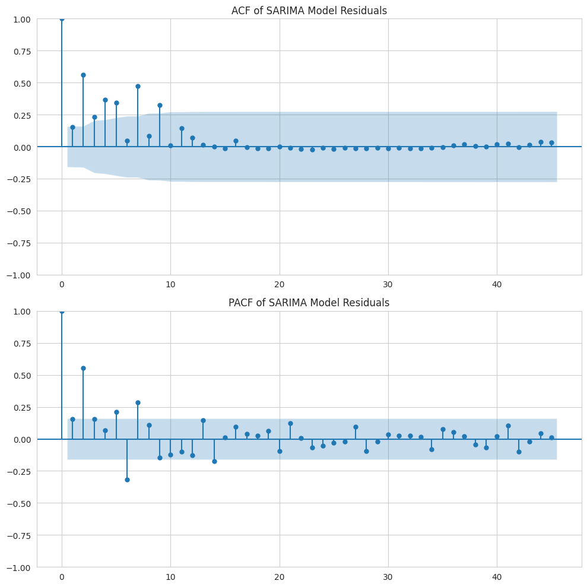

```python
# Checking heteroscedasticity
# We should look at the ACF and PACF plots of the squared residuals
# Plot ACF and PACF for squared residuals
res_2 = residuals**2
fig, ax = plt.subplots(2, 1, figsize=(10, 10))
# ACF
sm.graphics.tsa.plot_acf(res_2, lags=45, ax=ax[0])
ax[0].set_title('ACF of SARIMA Model Residuals')
# PACF
sm.graphics.tsa.plot_pacf(res_2, lags=45, ax=ax[1])
ax[1].set_title('PACF of SARIMA Model Residuals')

plt.tight_layout()
plt.show()
```

There are some significant spikes. Therefore, the constant variance assumption seems to be not satisfied.

Lets apply some formal tests to decide whether there is a heteroscedasticity problem or not.

```python
# Perform Breusch-Pagan test
import statsmodels.api as sm
import statsmodels.stats.api as sms
# The exog_het parameter should be the matrix of explanatory variables including the intercept
exog = sm.add_constant(arima_fitted.model.data.orig_endog)
bp_test = sms.het_breuschpagan(residuals, exog)

print("Breusch-Pagan Test:")
print(f"p-value: {bp_test[1]:.2f}")
```

```
Breusch-Pagan Test:
p-value: 0.00
```

```python
# Perform White test for heteroscedasticity
white_test = sms.het_white(residuals, exog)

print("\nWhite Test:")
print(f"LM statistic: {white_test[0]:.2f}")
print(f"p-value: {white_test[1]:.2f}")
print(f"F-statistic: {white_test[2]:.2f}")
print(f"F p-value: {white_test[3]:.2f}")
```

```
White Test:
LM statistic: 60.39
p-value: 0.00
F-statistic: 48.71
F p-value: 0.00
```

According to the White test, we can say that there are is heteroscedasticity problem.

> > *Decision Tree*

```
Training data shape: (154, 6)
Testing data shape: (12, 6)
Fitting 3 folds for each of 36 candidates, totalling 108 fits
```

```
Best parameters found: {'max_depth': 20, 'min_samples_leaf': 1, 'min_samples_split': 2}
Evaluation Metrics for Training Data:
**Root Mean Squared Error (RMSE):** 1.936959364564764e-18
**Mean Absolute Percentage Error (MAPE):** 2.703465157366453e-16
**Mean Absolute Scaled Error (MASE):** 1.9752329476728472e-22

Evaluation Metrics for Testing Data:
**Root Mean Squared Error (RMSE):** 4698.873404959989
**Mean Absolute Percentage Error (MAPE):** 9.704624903773135
**Mean Absolute Scaled Error (MASE):** 2.820970868438583
```

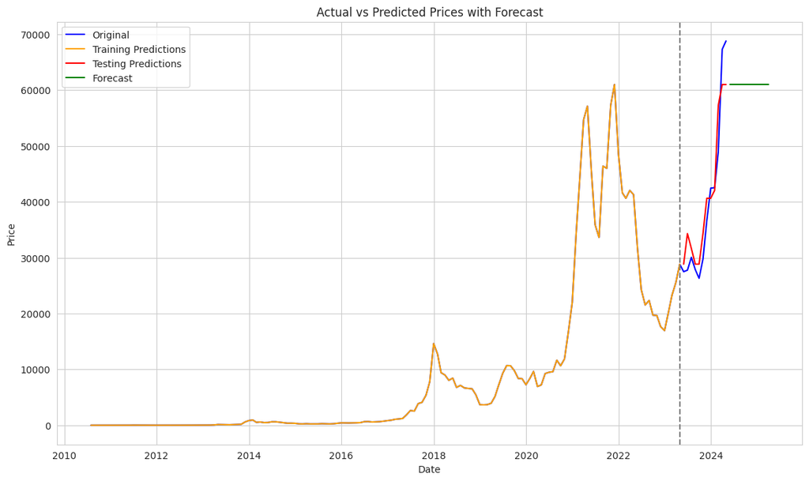

```python
import pandas as pd
import numpy as np
from sklearn.tree import DecisionTreeRegressor
from sklearn.metrics import mean_squared_error, mean_absolute_error
from sklearn.model_selection import GridSearchCV
import matplotlib.pyplot as plt

# Assuming monthly_data2 is already defined and available

# Split the dataset into training and testing sets
training_data = monthly_data2[monthly_data2.index < pd.to_datetime('2023-05-01')]
print("Training data shape:", training_data.shape)

testing_data = monthly_data2[monthly_data2.index >= pd.to_datetime('2023-05-01')]
print("Testing data shape:", testing_data.shape)

# Separate features and target variable
X_train = training_data[['Open', 'High', 'Low', 'Volume', 'Change']]
y_train = training_data['Price']

X_test = testing_data[['Open', 'High', 'Low', 'Volume', 'Change']]
y_test = testing_data['Price']

# Hyperparameter tuning using GridSearchCV
param_grid = {
    'max_depth': [5, 10, 20, None],
    'min_samples_split': [2, 5, 10],
    'min_samples_leaf': [1, 2, 4]
}

dt = DecisionTreeRegressor(random_state=42)
grid_search = GridSearchCV(estimator=dt, param_grid=param_grid, cv=3, n_jobs=-1, verbose=2, scoring='neg_mean_squared_error')
grid_search.fit(X_train, y_train)

# Best parameters from GridSearchCV
best_params = grid_search.best_params_
print(f"Best parameters found: {best_params}")

# Create and train the Decision Tree model with the best parameters
dt_model = DecisionTreeRegressor(**best_params, random_state=42)
dt_model.fit(X_train, y_train)

# Make predictions on the training and testing data
train_predictions = dt_model.predict(X_train)
test_predictions = dt_model.predict(X_test)

# Calculate evaluation metrics for training data
train_mse = mean_squared_error(y_train, train_predictions)
train_rmse = np.sqrt(train_mse)
train_mape = np.mean(np.abs((y_train - train_predictions) / y_train)) * 100

# Calculate evaluation metrics for testing data
test_mse = mean_squared_error(y_test, test_predictions)
test_rmse = np.sqrt(test_mse)
test_mape = np.mean(np.abs((y_test - test_predictions) / y_test)) * 100

# MASE calculation
# Calculate in-sample one-step naive forecast error
naive_forecast_train = training_data['Price'].shift(1)
naive_forecast_error_train = np.abs(training_data['Price'][1:] - naive_forecast_train[1:])
naive_mae_train = np.mean(naive_forecast_error_train)

# Calculate MASE for training data
train_mase = mean_absolute_error(y_train, train_predictions) / naive_mae_train

# Calculate in-sample one-step naive forecast error for testing data
naive_forecast_test = testing_data['Price'].shift(1)
naive_forecast_error_test = np.abs(testing_data['Price'][1:] - naive_forecast_test[1:])
naive_mae_test = np.mean(naive_forecast_error_test)

# Calculate MASE for testing data
test_mase = mean_absolute_error(y_test, test_predictions) / naive_mae_train

print("Evaluation Metrics for Training Data:")
print(f"**Root Mean Squared Error (RMSE):** {train_rmse}")
print(f"**Mean Absolute Percentage Error (MAPE):** {train_mape}")
print(f"**Mean Absolute Scaled Error (MASE):** {train_mase}")

print("\nEvaluation Metrics for Testing Data:")
print(f"**Root Mean Squared Error (RMSE):** {test_rmse}")
print(f"**Mean Absolute Percentage Error (MAPE):** {test_mape}")
print(f"**Mean Absolute Scaled Error (MASE):** {test_mase}")

# Extend the date index for forecast
forecast_dates = pd.date_range(start=testing_data.index[-1], periods=12, freq='M')[1:]

# Extend the features for forecast (you need to adjust this based on your specific forecasting method)
# For simplicity, we'll use the last available data point as a proxy for forecasting future values
last_available_data = testing_data.iloc[-1][['Open', 'High', 'Low', 'Volume', 'Change']].values
extended_features = np.tile(last_available_data, (len(forecast_dates), 1))

# Make predictions for the forecast period
forecast_predictions = dt_model.predict(extended_features)

# Plot actual vs predicted prices including forecast
plt.figure(figsize=(14, 8))

# Plot the original prices
plt.plot(monthly_data2.index, monthly_data2['Price'], label='Original', color='blue')

# Plot the training predictions
plt.plot(training_data.index, train_predictions, label='Training Predictions', color='orange')

# Plot the testing predictions
plt.plot(testing_data.index, test_predictions, label='Testing Predictions', color='red')

# Add a vertical line to separate training and testing data
plt.axvline(x=pd.to_datetime('2023-05-01'), color='gray', linestyle='--')

# Plot the forecast
plt.plot(forecast_dates, forecast_predictions, label='Forecast', color='green')

plt.xlabel('Date')
plt.ylabel('Price')
plt.title('Actual vs Predicted Prices with Forecast')
plt.legend()
plt.show()
```

> > Random Forest

```
Training data shape: (154, 6)
Testing data shape: (12, 6)
Fitting 3 folds for each of 486 candidates, totalling 1458 fits
```

```
Best parameters found: {'bootstrap': False, 'max_depth': 20, 'max_features': 'auto', 'min_samples_leaf': 1, 'min_samples_split': 2, 'n_estimators': 200}
```

```
Evaluation Metrics for Training Data:
**Root Mean Squared Error (RMSE):** 4.000432245156003e-11
**Mean Absolute Percentage Error (MAPE):** 2.1763620014793714e-13
**Mean Absolute Scaled Error (MASE):** 1.353002043653362e-14

Evaluation Metrics for Testing Data:
**Root Mean Squared Error (RMSE):** 4581.990377576255
**Mean Absolute Percentage Error (MAPE):** 7.747040710830889
**Mean Absolute Scaled Error (MASE):** 2.5046919192983528
```

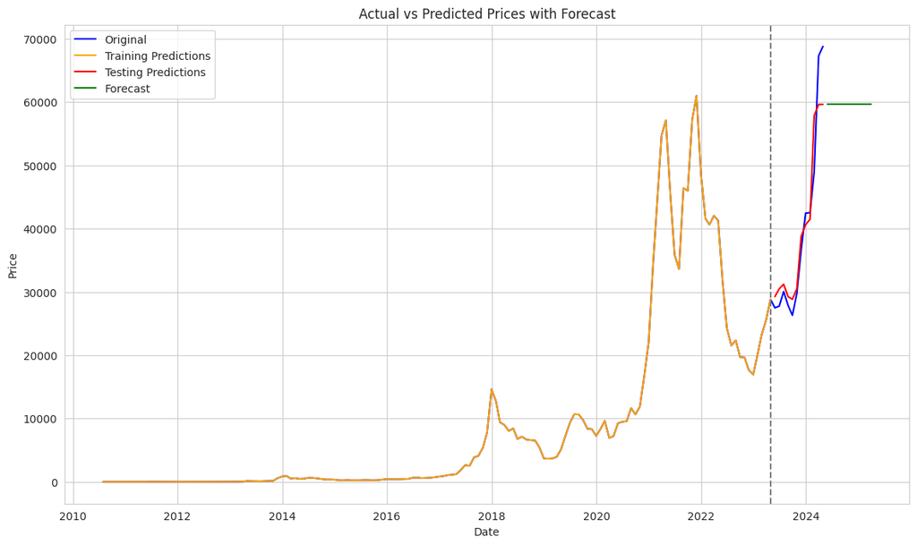

```python
import pandas as pd
import numpy as np
from sklearn.ensemble import RandomForestRegressor
from sklearn.metrics import mean_squared_error, mean_absolute_error
from sklearn.model_selection import GridSearchCV
import matplotlib.pyplot as plt

# Assuming monthly_data2 is already defined and available

# Split the dataset into training and testing sets
training_data = monthly_data2[monthly_data2.index < pd.to_datetime('2023-05-01')]
print("Training data shape:", training_data.shape)

testing_data = monthly_data2[monthly_data2.index >= pd.to_datetime('2023-05-01')]
print("Testing data shape:", testing_data.shape)

# Separate features and target variable
X_train = training_data[['Open', 'High', 'Low', 'Volume', 'Change']]
y_train = training_data['Price']

X_test = testing_data[['Open', 'High', 'Low', 'Volume', 'Change']]
y_test = testing_data['Price']

# Hyperparameter tuning using GridSearchCV
param_grid = {
    'n_estimators': [100, 200, 300],
    'max_features': ['auto', 'sqrt', 'log2'],
    'max_depth': [10, 20, None],
    'min_samples_split': [2, 5, 10],
    'min_samples_leaf': [1, 2, 4],
    'bootstrap': [True, False]
}

rf = RandomForestRegressor(random_state=42)
grid_search = GridSearchCV(estimator=rf, param_grid=param_grid, cv=3, n_jobs=-1, verbose=2, scoring='neg_mean_squared_error')
grid_search.fit(X_train, y_train)

# Best parameters from GridSearchCV
best_params = grid_search.best_params_
print(f"Best parameters found: {best_params}")

# Create and train the Random Forest model with the best parameters
rf_model = RandomForestRegressor(**best_params, random_state=42)
rf_model.fit(X_train, y_train)

# Make predictions on the training and testing data
train_predictions = rf_model.predict(X_train)
test_predictions = rf_model.predict(X_test)

# Calculate evaluation metrics for training data
train_mse = mean_squared_error(y_train, train_predictions)
train_rmse = np.sqrt(train_mse)
train_mape = np.mean(np.abs((y_train - train_predictions) / y_train)) * 100

# Calculate evaluation metrics for testing data
test_mse = mean_squared_error(y_test, test_predictions)
test_rmse = np.sqrt(test_mse)
test_mape = np.mean(np.abs((y_test - test_predictions) / y_test)) * 100

# MASE calculation
# Calculate in-sample one-step naive forecast error
naive_forecast_train = training_data['Price'].shift(1)
naive_forecast_error_train = np.abs(training_data['Price'][1:] - naive_forecast_train[1:])
naive_mae_train = np.mean(naive_forecast_error_train)

# Calculate MASE for training data
train_mase = mean_absolute_error(y_train, train_predictions) / naive_mae_train

# Calculate in-sample one-step naive forecast error for testing data
naive_forecast_test = testing_data['Price'].shift(1)
naive_forecast_error_test = np.abs(testing_data['Price'][1:] - naive_forecast_test[1:])
naive_mae_test = np.mean(naive_forecast_error_test)

# Calculate MASE for testing data
test_mase = mean_absolute_error(y_test, test_predictions) / naive_mae_train

print("Evaluation Metrics for Training Data:")
print(f"**Root Mean Squared Error (RMSE):** {train_rmse}")
print(f"**Mean Absolute Percentage Error (MAPE):** {train_mape}")
print(f"**Mean Absolute Scaled Error (MASE):** {train_mase}")

print("\nEvaluation Metrics for Testing Data:")
print(f"**Root Mean Squared Error (RMSE):** {test_rmse}")
print(f"**Mean Absolute Percentage Error (MAPE):** {test_mape}")
print(f"**Mean Absolute Scaled Error (MASE):** {test_mase}")

# Extend the date index for forecast
forecast_dates = pd.date_range(start=testing_data.index[-1], periods=12, freq='M')[1:]

# Extend the features for forecast (you need to adjust this based on your specific forecasting method)
# For simplicity, we'll use the last available data point as a proxy for forecasting future values
last_available_data = testing_data.iloc[-1][['Open', 'High', 'Low', 'Volume', 'Change']].values
extended_features = np.tile(last_available_data, (len(forecast_dates), 1))

# Make predictions for the forecast period
forecast_predictions = rf_model.predict(extended_features)

# Plot actual vs predicted prices including forecast
plt.figure(figsize=(14, 8))

# Plot the original prices
plt.plot(monthly_data2.index, monthly_data2['Price'], label='Original', color='blue')

# Plot the training predictions
plt.plot(training_data.index, train_predictions, label='Training Predictions', color='orange')

# Plot the testing predictions
plt.plot(testing_data.index, test_predictions, label='Testing Predictions', color='red')

# Add a vertical line to separate training and testing data
plt.axvline(x=pd.to_datetime('2023-05-01'), color='gray', linestyle='--')

# Plot the forecast
plt.plot(forecast_dates, forecast_predictions, label='Forecast', color='green')

plt.xlabel('Date')
plt.ylabel('Price')
plt.title('Actual vs Predicted Prices with Forecast')
plt.legend()
plt.show()
```

> > Gradient Boosting

```
Training data shape: (154, 6)
Testing data shape: (12, 6)
Fitting 3 folds for each of 486 candidates, totalling 1458 fits
```

```
Best parameters found: {'learning_rate': 0.1, 'max_depth': 7, 'min_samples_leaf': 1, 'min_samples_split': 5, 'n_estimators': 300, 'subsample': 1.0}
Evaluation Metrics for Training Data:
**Root Mean Squared Error (RMSE):** 0.0005293367976441755
**Mean Absolute Percentage Error (MAPE):** 0.014036685188379921
**Mean Absolute Scaled Error (MASE):** 2.959634949780049e-07

Evaluation Metrics for Testing Data:
**Root Mean Squared Error (RMSE):** 3824.7755645272855
**Mean Absolute Percentage Error (MAPE):** 6.046337254515191
**Mean Absolute Scaled Error (MASE):** 2.0186254171284452
```

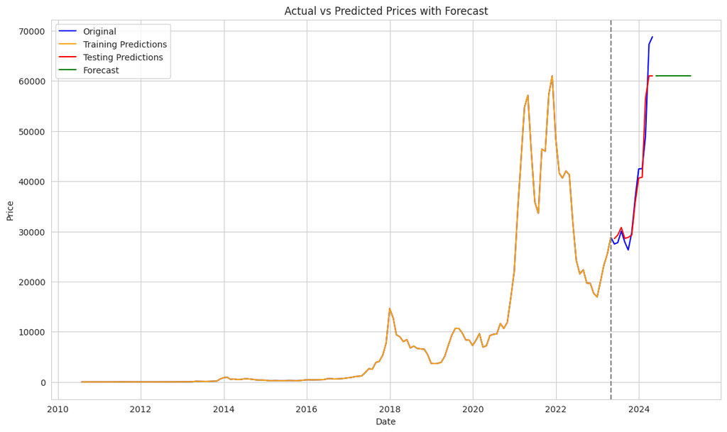

```python
import pandas as pd
import numpy as np
from sklearn.ensemble import GradientBoostingRegressor
from sklearn.metrics import mean_squared_error, mean_absolute_error
from sklearn.model_selection import GridSearchCV
import matplotlib.pyplot as plt

# Assuming monthly_data2 is already defined and available

# Split the dataset into training and testing sets
training_data = monthly_data2[monthly_data2.index < pd.to_datetime('2023-05-01')]
print("Training data shape:", training_data.shape)

testing_data = monthly_data2[monthly_data2.index >= pd.to_datetime('2023-05-01')]
print("Testing data shape:", testing_data.shape)

# Separate features and target variable
X_train = training_data[['Open', 'High', 'Low', 'Volume', 'Change']]
y_train = training_data['Price']

X_test = testing_data[['Open', 'High', 'Low', 'Volume', 'Change']]
y_test = testing_data['Price']

# Hyperparameter tuning using GridSearchCV
param_grid = {
    'n_estimators': [100, 200, 300],
    'learning_rate': [0.01, 0.1, 0.2],
    'max_depth': [3, 5, 7],
    'min_samples_split': [2, 5, 10],
    'min_samples_leaf': [1, 2, 4],
    'subsample': [0.8, 1.0]
}

gbr = GradientBoostingRegressor(random_state=42)
grid_search = GridSearchCV(estimator=gbr, param_grid=param_grid, cv=3, n_jobs=-1, verbose=2, scoring='neg_mean_squared_error')
grid_search.fit(X_train, y_train)

# Best parameters from GridSearchCV
best_params = grid_search.best_params_
print(f"Best parameters found: {best_params}")

# Create and train the Gradient Boosting model with the best parameters
gbr_model = GradientBoostingRegressor(**best_params, random_state=42)
gbr_model.fit(X_train, y_train)

# Make predictions on the training and testing data
train_predictions = gbr_model.predict(X_train)
test_predictions = gbr_model.predict(X_test)

# Calculate evaluation metrics for training data
train_mse = mean_squared_error(y_train, train_predictions)
train_rmse = np.sqrt(train_mse)
train_mape = np.mean(np.abs((y_train - train_predictions) / y_train)) * 100

# Calculate evaluation metrics for testing data
test_mse = mean_squared_error(y_test, test_predictions)
test_rmse = np.sqrt(test_mse)
test_mape = np.mean(np.abs((y_test - test_predictions) / y_test)) * 100

# MASE calculation
# Calculate in-sample one-step naive forecast error
naive_forecast_train = training_data['Price'].shift(1)
naive_forecast_error_train = np.abs(training_data['Price'][1:] - naive_forecast_train[1:])
naive_mae_train = np.mean(naive_forecast_error_train)

# Calculate MASE for training data
train_mase = mean_absolute_error(y_train, train_predictions) / naive_mae_train

# Calculate in-sample one-step naive forecast error for testing data
naive_forecast_test = testing_data['Price'].shift(1)
naive_forecast_error_test = np.abs(testing_data['Price'][1:] - naive_forecast_test[1:])
naive_mae_test = np.mean(naive_forecast_error_test)

# Calculate MASE for testing data
test_mase = mean_absolute_error(y_test, test_predictions) / naive_mae_train

print("Evaluation Metrics for Training Data:")
print(f"**Root Mean Squared Error (RMSE):** {train_rmse}")
print(f"**Mean Absolute Percentage Error (MAPE):** {train_mape}")
print(f"**Mean Absolute Scaled Error (MASE):** {train_mase}")

print("\nEvaluation Metrics for Testing Data:")
print(f"**Root Mean Squared Error (RMSE):** {test_rmse}")
print(f"**Mean Absolute Percentage Error (MAPE):** {test_mape}")
print(f"**Mean Absolute Scaled Error (MASE):** {test_mase}")

# Extend the date index for forecast
forecast_dates = pd.date_range(start=testing_data.index[-1], periods=12, freq='M')[1:]

# Extend the features for forecast (you need to adjust this based on your specific forecasting method)
# For simplicity, we'll use the last available data point as a proxy for forecasting future values
last_available_data = testing_data.iloc[-1][['Open', 'High', 'Low', 'Volume', 'Change']].values
extended_features = np.tile(last_available_data, (len(forecast_dates), 1))

# Make predictions for the forecast period
forecast_predictions = gbr_model.predict(extended_features)

# Plot actual vs predicted prices including forecast
plt.figure(figsize=(14, 8))

# Plot the original prices
plt.plot(monthly_data2.index, monthly_data2['Price'], label='Original', color='blue')

# Plot the training predictions
plt.plot(training_data.index, train_predictions, label='Training Predictions', color='orange')

# Plot the testing predictions
plt.plot(testing_data.index, test_predictions, label='Testing Predictions', color='red')

# Add a vertical line to separate training and testing data
plt.axvline(x=pd.to_datetime('2023-05-01'), color='gray', linestyle='--')

# Plot the forecast
plt.plot(forecast_dates, forecast_predictions, label='Forecast', color='green')

plt.xlabel('Date')
plt.ylabel('Price')
plt.title('Actual vs Predicted Prices with Forecast')
plt.legend()
plt.show()
```

> > AdaBoost

```
Training data shape: (154, 6)
Testing data shape: (12, 6)
Fitting 3 folds for each of 9 candidates, totalling 27 fits
```

```
Best parameters found: {'learning_rate': 0.01, 'n_estimators': 200}
Evaluation Metrics for Training Data:
**Root Mean Squared Error (RMSE):** 964.8219823501335
**Mean Absolute Percentage Error (MAPE):** 11776.574793218855
**Mean Absolute Scaled Error (MASE):** 0.47455091103186

Evaluation Metrics for Testing Data:
**Root Mean Squared Error (RMSE):** 5495.663521855999
**Mean Absolute Percentage Error (MAPE):** 10.354778079674649
**Mean Absolute Scaled Error (MASE):** 3.128498215718622
```

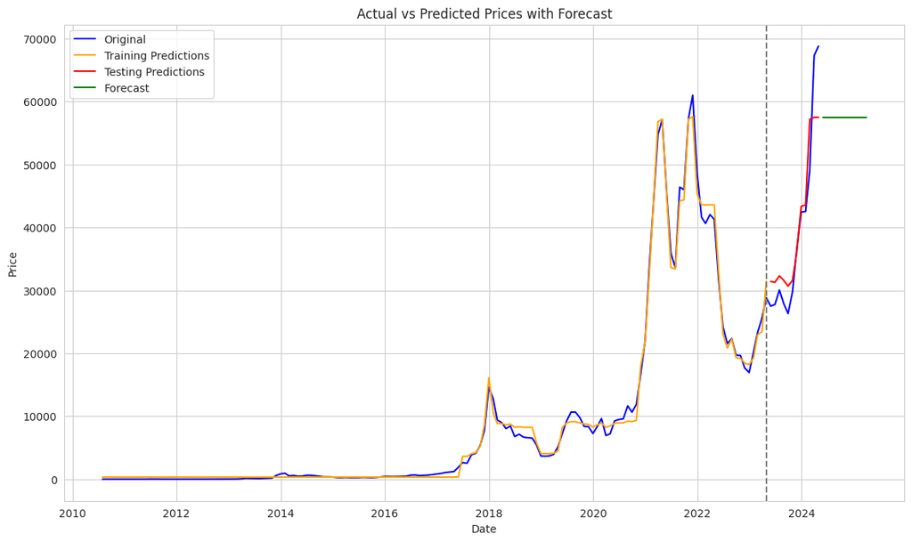

```python
import pandas as pd
import numpy as np
from sklearn.ensemble import AdaBoostRegressor
from sklearn.metrics import mean_squared_error, mean_absolute_error
from sklearn.model_selection import GridSearchCV
import matplotlib.pyplot as plt

# Assuming monthly_data2 is already defined and available

# Split the dataset into training and testing sets
training_data = monthly_data2[monthly_data2.index < pd.to_datetime('2023-05-01')]
print("Training data shape:", training_data.shape)

testing_data = monthly_data2[monthly_data2.index >= pd.to_datetime('2023-05-01')]
print("Testing data shape:", testing_data.shape)

# Separate features and target variable
X_train = training_data[['Open', 'High', 'Low', 'Volume', 'Change']]
y_train = training_data['Price']

X_test = testing_data[['Open', 'High', 'Low', 'Volume', 'Change']]
y_test = testing_data['Price']

# Hyperparameter tuning using GridSearchCV
param_grid = {
    'n_estimators': [50, 100, 200],
    'learning_rate': [0.01, 0.1, 1.0]
}

abr = AdaBoostRegressor(random_state=42)
grid_search = GridSearchCV(estimator=abr, param_grid=param_grid, cv=3, n_jobs=-1, verbose=2, scoring='neg_mean_squared_error')
grid_search.fit(X_train, y_train)

# Best parameters from GridSearchCV
best_params = grid_search.best_params_
print(f"Best parameters found: {best_params}")

# Create and train the AdaBoost model with the best parameters
abr_model = AdaBoostRegressor(**best_params, random_state=42)
abr_model.fit(X_train, y_train)

# Make predictions on the training and testing data
train_predictions = abr_model.predict(X_train)
test_predictions = abr_model.predict(X_test)

# Calculate evaluation metrics for training data
train_mse = mean_squared_error(y_train, train_predictions)
train_rmse = np.sqrt(train_mse)
train_mape = np.mean(np.abs((y_train - train_predictions) / y_train)) * 100

# Calculate evaluation metrics for testing data
test_mse = mean_squared_error(y_test, test_predictions)
test_rmse = np.sqrt(test_mse)
test_mape = np.mean(np.abs((y_test - test_predictions) / y_test)) * 100

# MASE calculation
# Calculate in-sample one-step naive forecast error
naive_forecast_train = training_data['Price'].shift(1)
naive_forecast_error_train = np.abs(training_data['Price'][1:] - naive_forecast_train[1:])
naive_mae_train = np.mean(naive_forecast_error_train)

# Calculate MASE for training data
train_mase = mean_absolute_error(y_train, train_predictions) / naive_mae_train

# Calculate in-sample one-step naive forecast error for testing data
naive_forecast_test = testing_data['Price'].shift(1)
naive_forecast_error_test = np.abs(testing_data['Price'][1:] - naive_forecast_test[1:])
naive_mae_test = np.mean(naive_forecast_error_test)

# Calculate MASE for testing data
test_mase = mean_absolute_error(y_test, test_predictions) / naive_mae_train

print("Evaluation Metrics for Training Data:")
print(f"**Root Mean Squared Error (RMSE):** {train_rmse}")
print(f"**Mean Absolute Percentage Error (MAPE):** {train_mape}")
print(f"**Mean Absolute Scaled Error (MASE):** {train_mase}")

print("\nEvaluation Metrics for Testing Data:")
print(f"**Root Mean Squared Error (RMSE):** {test_rmse}")
print(f"**Mean Absolute Percentage Error (MAPE):** {test_mape}")
print(f"**Mean Absolute Scaled Error (MASE):** {test_mase}")

# Extend the date index for forecast
forecast_dates = pd.date_range(start=testing_data.index[-1], periods=12, freq='M')[1:]

# Extend the features for forecast (you need to adjust this based on your specific forecasting method)
# For simplicity, we'll use the last available data point as a proxy for forecasting future values
last_available_data = testing_data.iloc[-1][['Open', 'High', 'Low', 'Volume', 'Change']].values
extended_features = np.tile(last_available_data, (len(forecast_dates), 1))

# Make predictions for the forecast period
forecast_predictions = abr_model.predict(extended_features)

# Plot actual vs predicted prices including forecast
plt.figure(figsize=(14, 8))

# Plot the original prices
plt.plot(monthly_data2.index, monthly_data2['Price'], label='Original', color='blue')

# Plot the training predictions
plt.plot(training_data.index, train_predictions, label='Training Predictions', color='orange')

# Plot the testing predictions
plt.plot(testing_data.index, test_predictions, label='Testing Predictions', color='red')

# Add a vertical line to separate training and testing data
plt.axvline(x=pd.to_datetime('2023-05-01'), color='gray', linestyle='--')

# Plot the forecast
plt.plot(forecast_dates, forecast_predictions, label='Forecast', color='green')

plt.xlabel('Date')
plt.ylabel('Price')
plt.title('Actual vs Predicted Prices with Forecast')
plt.legend()
plt.show()
```

> > CatBoost

```python
pip install catboost
```

```
Training data shape: (154, 6)
Testing data shape: (12, 6)
Fitting 3 folds for each of 81 candidates, totalling 243 fits
```

```
Best parameters found: {'depth': 4, 'iterations': 200, 'l2_leaf_reg': 3, 'learning_rate': 0.2}
Evaluation Metrics for Training Data:
**Root Mean Squared Error (RMSE):** 114.61793519445449
**Mean Absolute Percentage Error (MAPE):** 1523.872599413331
**Mean Absolute Scaled Error (MASE):** 0.058631861758322426

Evaluation Metrics for Testing Data:
**Root Mean Squared Error (RMSE):** 4489.277904463556
**Mean Absolute Percentage Error (MAPE):** 6.221575313844908
**Mean Absolute Scaled Error (MASE):** 2.1972423517746225
```

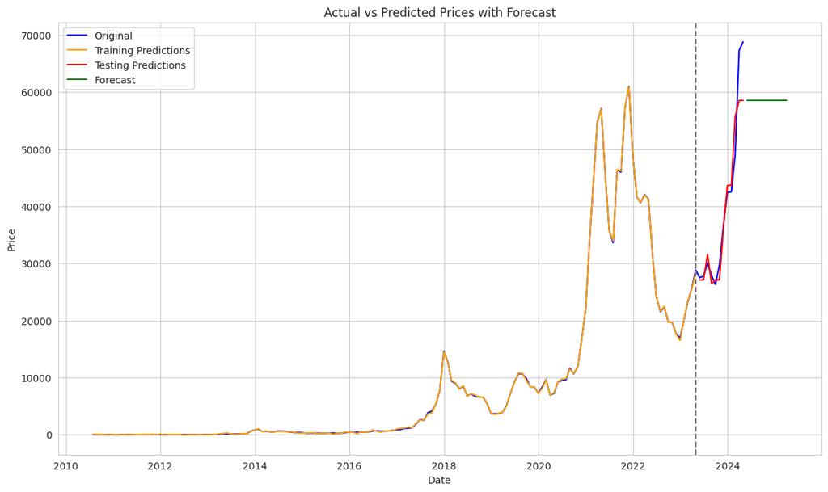

```python
import pandas as pd
import numpy as np
from catboost import CatBoostRegressor
from sklearn.metrics import mean_squared_error, mean_absolute_error
from sklearn.model_selection import GridSearchCV
import matplotlib.pyplot as plt

# Assuming monthly_data2 is already defined and available

# Split the dataset into training and testing sets
training_data = monthly_data2[monthly_data2.index < pd.to_datetime('2023-05-01')]
print("Training data shape:", training_data.shape)

testing_data = monthly_data2[monthly_data2.index >= pd.to_datetime('2023-05-01')]
print("Testing data shape:", testing_data.shape)

# Separate features and target variable
X_train = training_data[['Open', 'High', 'Low', 'Volume', 'Change']]
y_train = training_data['Price']

X_test = testing_data[['Open', 'High', 'Low', 'Volume', 'Change']]
y_test = testing_data['Price']

# Hyperparameter tuning using GridSearchCV
param_grid = {
    'iterations': [100, 200, 300],
    'depth': [4, 6, 8],
    'learning_rate': [0.01, 0.1, 0.2],
    'l2_leaf_reg': [1, 3, 5]
}

catboost_model = CatBoostRegressor(random_state=42, silent=True)
grid_search = GridSearchCV(estimator=catboost_model, param_grid=param_grid, cv=3, n_jobs=-1, verbose=2, scoring='neg_mean_squared_error')
grid_search.fit(X_train, y_train)

# Best parameters from GridSearchCV
best_params = grid_search.best_params_
print(f"Best parameters found: {best_params}")

# Create and train the CatBoost model with the best parameters
catboost_model = CatBoostRegressor(**best_params, random_state=42, silent=True)
catboost_model.fit(X_train, y_train)

# Make predictions on the training and testing data
train_predictions = catboost_model.predict(X_train)
test_predictions = catboost_model.predict(X_test)

# Calculate evaluation metrics for training data
train_mse = mean_squared_error(y_train, train_predictions)
train_rmse = np.sqrt(train_mse)
train_mape = np.mean(np.abs((y_train - train_predictions) / y_train)) * 100

# Calculate evaluation metrics for testing data
test_mse = mean_squared_error(y_test, test_predictions)
test_rmse = np.sqrt(test_mse)
test_mape = np.mean(np.abs((y_test - test_predictions) / y_test)) * 100

# MASE calculation
# Calculate in-sample one-step naive forecast error
naive_forecast_train = training_data['Price'].shift(1)
naive_forecast_error_train = np.abs(training_data['Price'][1:] - naive_forecast_train[1:])
naive_mae_train = np.mean(naive_forecast_error_train)

# Calculate MASE for training data
train_mase = mean_absolute_error(y_train, train_predictions) / naive_mae_train

# Calculate in-sample one-step naive forecast error for testing data
naive_forecast_test = testing_data['Price'].shift(1)
naive_forecast_error_test = np.abs(testing_data['Price'][1:] - naive_forecast_test[1:])
naive_mae_test = np.mean(naive_forecast_error_test)

# Calculate MASE for testing data
test_mase = mean_absolute_error(y_test, test_predictions) / naive_mae_train

print("Evaluation Metrics for Training Data:")
print(f"**Root Mean Squared Error (RMSE):** {train_rmse}")
print(f"**Mean Absolute Percentage Error (MAPE):** {train_mape}")
print(f"**Mean Absolute Scaled Error (MASE):** {train_mase}")

print("\nEvaluation Metrics for Testing Data:")
print(f"**Root Mean Squared Error (RMSE):** {test_rmse}")
print(f"**Mean Absolute Percentage Error (MAPE):** {test_mape}")
print(f"**Mean Absolute Scaled Error (MASE):** {test_mase}")

# Extend the date index for forecast
forecast_dates = pd.date_range(start=testing_data.index[-1], periods=12, freq='M')[1:]

# Extend the features for forecast (you need to adjust this based on your specific forecasting method)
# For simplicity, we'll use the last available data point as a proxy for forecasting future values
last_available_data = testing_data.iloc[-1][['Open', 'High', 'Low', 'Volume', 'Change']].values
extended_features = np.tile(last_available_data, (len(forecast_dates), 1))

# Make predictions for the forecast period
forecast_predictions = catboost_model.predict(extended_features)

# Plot actual vs predicted prices including forecast
plt.figure(figsize=(14, 8))

# Plot the original prices
plt.plot(monthly_data2.index, monthly_data2['Price'], label='Original', color='blue')

# Plot the training predictions
plt.plot(training_data.index, train_predictions, label='Training Predictions', color='orange')

# Plot the testing predictions
plt.plot(testing_data.index, test_predictions, label='Testing Predictions', color='red')

# Add a vertical line to separate training and testing data
plt.axvline(x=pd.to_datetime('2023-05-01'), color='gray', linestyle='--')

# Plot the forecast
plt.plot(forecast_dates, forecast_predictions, label='Forecast', color='green')

plt.xlabel('Date')
plt.ylabel('Price')
plt.title('Actual vs Predicted Prices with Forecast')
plt.legend()
plt.show()
```

> > LightGBM

[output not shown]

[output cut: 168 more lines]

```
[LightGBM] [Warning] No further splits with positive gain, best gain: -inf
[LightGBM] [Warning] No further splits with positive gain, best gain: -inf
[LightGBM] [Warning] No further splits with positive gain, best gain: -inf
[LightGBM] [Warning] No further splits with positive gain, best gain: -inf
[LightGBM] [Warning] No further splits with positive gain, best gain: -inf
[LightGBM] [Warning] No further splits with positive gain, best gain: -inf
Evaluation Metrics for Training Data:
**Root Mean Squared Error (RMSE):** 2268.1143407089053
**Mean Absolute Percentage Error (MAPE):** 3519.825565319987
**Mean Absolute Scaled Error (MASE):** 0.8539024452553808

Evaluation Metrics for Testing Data:
**Root Mean Squared Error (RMSE):** 16607.122379651646
**Mean Absolute Percentage Error (MAPE):** 41.995026719600276
**Mean Absolute Scaled Error (MASE):** 10.611915220729587
```

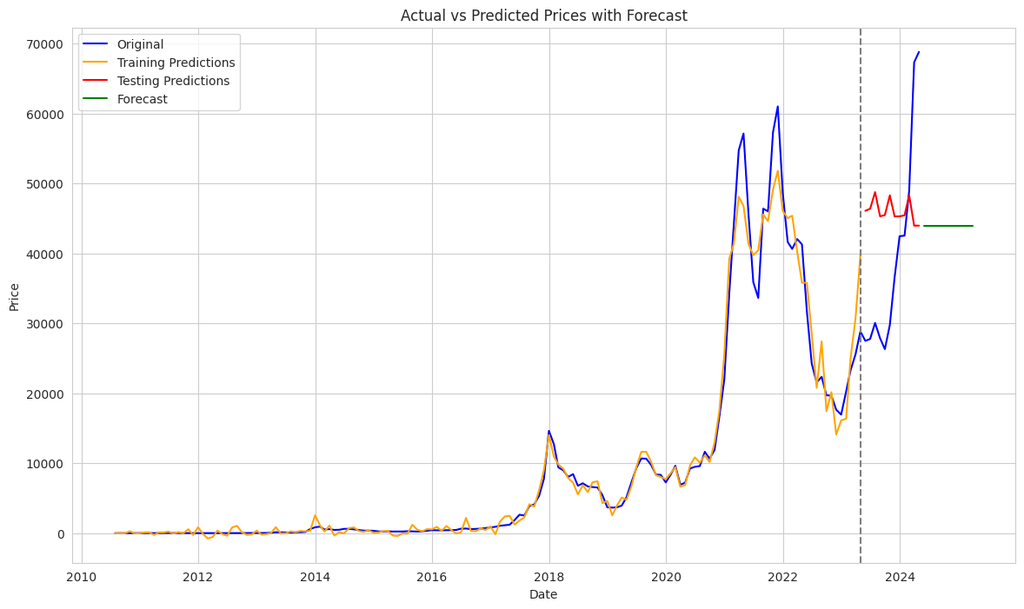

```python
import pandas as pd
import numpy as np
from lightgbm import LGBMRegressor
from sklearn.metrics import mean_squared_error, mean_absolute_error
from sklearn.model_selection import GridSearchCV
import matplotlib.pyplot as plt

# Assuming monthly_data2 is already defined and available

# Split the dataset into training and testing sets
training_data = monthly_data2[monthly_data2.index < pd.to_datetime('2023-05-01')]
print("Training data shape:", training_data.shape)

testing_data = monthly_data2[monthly_data2.index >= pd.to_datetime('2023-05-01')]
print("Testing data shape:", testing_data.shape)

# Separate features and target variable
X_train = training_data[['Open', 'High', 'Low', 'Volume', 'Change']]
y_train = training_data['Price']

X_test = testing_data[['Open', 'High', 'Low', 'Volume', 'Change']]
y_test = testing_data['Price']

# Hyperparameter tuning using GridSearchCV
param_grid = {
    'n_estimators': [100, 200, 300],
    'num_leaves': [31, 50, 100],
    'learning_rate': [0.01, 0.1, 0.2],
    'boosting_type': ['gbdt', 'dart', 'goss'],
    'max_depth': [-1, 10, 20]
}

lgbm = LGBMRegressor(random_state=42)
grid_search = GridSearchCV(estimator=lgbm, param_grid=param_grid, cv=3, n_jobs=-1, verbose=2, scoring='neg_mean_squared_error')
grid_search.fit(X_train, y_train)

# Best parameters from GridSearchCV
best_params = grid_search.best_params_
print(f"Best parameters found: {best_params}")

# Create and train the LightGBM model with the best parameters
lgbm_model = LGBMRegressor(**best_params, random_state=42)
lgbm_model.fit(X_train, y_train)

# Make predictions on the training and testing data
train_predictions = lgbm_model.predict(X_train)
test_predictions = lgbm_model.predict(X_test)

# Calculate evaluation metrics for training data
train_mse = mean_squared_error(y_train, train_predictions)
train_rmse = np.sqrt(train_mse)
train_mape = np.mean(np.abs((y_train - train_predictions) / y_train)) * 100

# Calculate evaluation metrics for testing data
test_mse = mean_squared_error(y_test, test_predictions)
test_rmse = np.sqrt(test_mse)
test_mape = np.mean(np.abs((y_test - test_predictions) / y_test)) * 100

# MASE calculation
# Calculate in-sample one-step naive forecast error
naive_forecast_train = training_data['Price'].shift(1)
naive_forecast_error_train = np.abs(training_data['Price'][1:] - naive_forecast_train[1:])
naive_mae_train = np.mean(naive_forecast_error_train)

# Calculate MASE for training data
train_mase = mean_absolute_error(y_train, train_predictions) / naive_mae_train

# Calculate in-sample one-step naive forecast error for testing data
naive_forecast_test = testing_data['Price'].shift(1)
naive_forecast_error_test = np.abs(testing_data['Price'][1:] - naive_forecast_test[1:])
naive_mae_test = np.mean(naive_forecast_error_test)

# Calculate MASE for testing data
test_mase = mean_absolute_error(y_test, test_predictions) / naive_mae_train

print("Evaluation Metrics for Training Data:")
print(f"**Root Mean Squared Error (RMSE):** {train_rmse}")
print(f"**Mean Absolute Percentage Error (MAPE):** {train_mape}")
print(f"**Mean Absolute Scaled Error (MASE):** {train_mase}")

print("\nEvaluation Metrics for Testing Data:")
print(f"**Root Mean Squared Error (RMSE):** {test_rmse}")
print(f"**Mean Absolute Percentage Error (MAPE):** {test_mape}")
print(f"**Mean Absolute Scaled Error (MASE):** {test_mase}")

# Extend the date index for forecast
forecast_dates = pd.date_range(start=testing_data.index[-1], periods=12, freq='M')[1:]

# Extend the features for forecast (you need to adjust this based on your specific forecasting method)
# For simplicity, we'll use the last available data point as a proxy for forecasting future values
last_available_data = testing_data.iloc[-1][['Open', 'High', 'Low', 'Volume', 'Change']].values
extended_features = np.tile(last_available_data, (len(forecast_dates), 1))

# Make predictions for the forecast period
forecast_predictions = lgbm_model.predict(extended_features)

# Plot actual vs predicted prices including forecast
plt.figure(figsize=(14, 8))

# Plot the original prices
plt.plot(monthly_data2.index, monthly_data2['Price'], label='Original', color='blue')

# Plot the training predictions
plt.plot(training_data.index, train_predictions, label='Training Predictions', color='orange')

# Plot the testing predictions
plt.plot(testing_data.index, test_predictions, label='Testing Predictions', color='red')

# Add a vertical line to separate training and testing data
plt.axvline(x=pd.to_datetime('2023-05-01'), color='gray', linestyle='--')

# Plot the forecast
plt.plot(forecast_dates, forecast_predictions, label='Forecast', color='green')

plt.xlabel('Date')
plt.ylabel('Price')
plt.title('Actual vs Predicted Prices with Forecast')
plt.legend()
plt.show()
```

Based on Mean Absolute Scaled Error (MASE) values: Train/Test

- LightGBM: 0.85 - 10.61
- CatBoost: 0.06 - 2.19
- AdaBoost: 0.47 - 3.12
- Random Forest: 0.01 - 2.50
- Gradient Boosting: 0.01 - 2.01
- Decision Tree: 0.01 - 2.82
- ARIMA(4,1,2): 0.86 - 9.02
- ARIMA(1,1,2): 0.87 - 8.34

Based on these scores, the best three models are Gradient Boosting, CatBoost and Random Forest, respectively.

```
Training data shape: (154, 8)
Testing data shape: (12, 8)
Fitting 3 folds for each of 540 candidates, totalling 1620 fits
Best parameters found: {'border_count': 64, 'depth': 4, 'iterations': 300, 'l2_leaf_reg': 9, 'learning_rate': 0.2}
Evaluation Metrics for Training Data:
**Root Mean Squared Error (RMSE):** 197.55995265135746
**Mean Absolute Percentage Error (MAPE):** 2508.4104222240153
**Mean Absolute Scaled Error (MASE):** 0.10367474714235914

Evaluation Metrics for Testing Data:
**Root Mean Squared Error (RMSE):** 5037.5424765825
**Mean Absolute Percentage Error (MAPE):** 6.212888081947126
**Mean Absolute Scaled Error (MASE):** 2.116249143749144
```

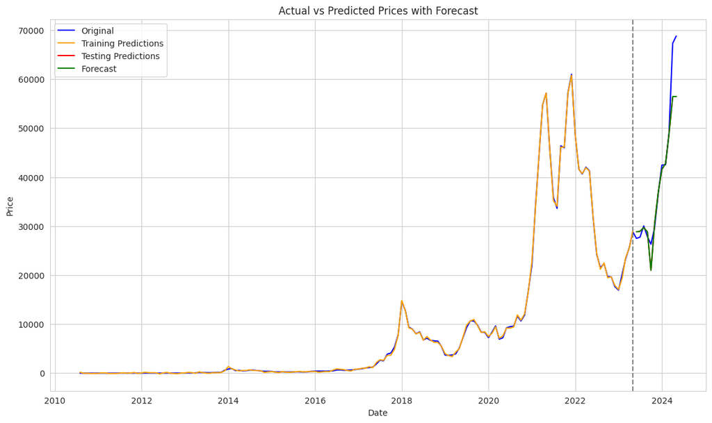

```python
import pandas as pd
import numpy as np
from catboost import CatBoostRegressor
from sklearn.metrics import mean_squared_error, mean_absolute_error
from sklearn.model_selection import GridSearchCV
import matplotlib.pyplot as plt

# Assuming monthly_data2 is already defined and available

# Split the dataset into training and testing sets
training_data = monthly_data2[monthly_data2.index < pd.to_datetime('2023-05-01')]
print("Training data shape:", training_data.shape)

testing_data = monthly_data2[monthly_data2.index >= pd.to_datetime('2023-05-01')]
print("Testing data shape:", testing_data.shape)

# Separate features and target variable
X_train = training_data[['Open', 'High', 'Low', 'Volume', 'Change']]
y_train = training_data['Price']

X_test = testing_data[['Open', 'High', 'Low', 'Volume', 'Change']]
y_test = testing_data['Price']

# Hyperparameter tuning using GridSearchCV
param_grid = {
    'iterations': [100, 200, 300],
    'depth': [4, 6, 8, 10],
    'learning_rate': [0.01, 0.1, 0.2],
    'l2_leaf_reg': [1, 3, 5, 7, 9],
    'border_count': [32, 64, 128]
}

catboost = CatBoostRegressor(random_seed=42, silent=True)
grid_search = GridSearchCV(estimator=catboost, param_grid=param_grid, cv=3, n_jobs=-1, verbose=2, scoring='neg_mean_squared_error')
grid_search.fit(X_train, y_train)

# Best parameters from GridSearchCV
best_params = grid_search.best_params_
print(f"Best parameters found: {best_params}")

# Create and train the CatBoost model with the best parameters
catboost_model = CatBoostRegressor(**best_params, random_seed=42, silent=True)
catboost_model.fit(X_train, y_train)

# Make predictions on the training and testing data
train_predictions = catboost_model.predict(X_train)
test_predictions = catboost_model.predict(X_test)

# Calculate evaluation metrics for training data
train_mse = mean_squared_error(y_train, train_predictions)
train_rmse = np.sqrt(train_mse)
train_mape = np.mean(np.abs((y_train - train_predictions) / y_train)) * 100

# Calculate evaluation metrics for testing data
test_mse = mean_squared_error(y_test, test_predictions)
test_rmse = np.sqrt(test_mse)
test_mape = np.mean(np.abs((y_test - test_predictions) / y_test)) * 100

# MASE calculation
# Calculate in-sample one-step naive forecast error
naive_forecast_train = training_data['Price'].shift(1)
naive_forecast_error_train = np.abs(training_data['Price'][1:] - naive_forecast_train[1:])
naive_mae_train = np.mean(naive_forecast_error_train)

# Calculate MASE for training data
train_mase = mean_absolute_error(y_train, train_predictions) / naive_mae_train

# Calculate in-sample one-step naive forecast error for testing data
naive_forecast_test = testing_data['Price'].shift(1)
naive_forecast_error_test = np.abs(testing_data['Price'][1:] - naive_forecast_test[1:])
naive_mae_test = np.mean(naive_forecast_error_test)

# Calculate MASE for testing data
test_mase = mean_absolute_error(y_test, test_predictions) / naive_mae_train

print("Evaluation Metrics for Training Data:")
print(f"**Root Mean Squared Error (RMSE):** {train_rmse}")
print(f"**Mean Absolute Percentage Error (MAPE):** {train_mape}")
print(f"**Mean Absolute Scaled Error (MASE):** {train_mase}")

print("\nEvaluation Metrics for Testing Data:")
print(f"**Root Mean Squared Error (RMSE):** {test_rmse}")
print(f"**Mean Absolute Percentage Error (MAPE):** {test_mape}")
print(f"**Mean Absolute Scaled Error (MASE):** {test_mase}")

# Extend the date index for forecast
forecast_dates = pd.date_range(start=testing_data.index[-1], periods=12, freq='M')[1:]

# Extend the features for forecast (you need to adjust this based on your specific forecasting method)
# For simplicity, we'll use the last available data point as a proxy for forecasting future values
last_available_data = testing_data.iloc[-1][['Open', 'High', 'Low', 'Volume', 'Change']].values
extended_features = np.tile(last_available_data, (len(forecast_dates), 1))


# Create lagged features for forecasting
def create_lagged_features(data, lags=12):
    df = data.copy()
    for lag in range(1, lags + 1):
        df[f'lag_{lag}'] = df['Price'].shift(lag)
    df.dropna(inplace=True)
    return df

# Extend the dataset with lagged features
extended_data = create_lagged_features(monthly_data2)
forecasting_data_extended = extended_data[extended_data.index >= pd.to_datetime('2023-05-01')]
X_forecast_extended = forecasting_data_extended.drop(columns=['Price'])
forecast_predictions = catboost_model.predict(X_forecast_extended)

# Make predictions for the forecast period
#forecast_predictions = catboost_model.predict(extended_features)

# Plot actual vs predicted prices including forecast
plt.figure(figsize=(14, 8))

# Plot the original prices
plt.plot(monthly_data2.index, monthly_data2['Price'], label='Original', color='blue')

# Plot the training predictions
plt.plot(training_data.index, train_predictions, label='Training Predictions', color='orange')

# Plot the testing predictions
plt.plot(testing_data.index, test_predictions, label='Testing Predictions', color='red')

# Add a vertical line to separate training and testing data
plt.axvline(x=pd.to_datetime('2023-05-01'), color='gray', linestyle='--')

# Plot the forecast
plt.plot(X_forecast_extended.index, forecast_predictions, label='Forecast', color='green')

plt.xlabel('Date')
plt.ylabel('Price')
plt.title('Actual vs Predicted Prices with Forecast')
plt.legend()
plt.show()
```

> > Random Forest - Gradient Boosting Hybrid Model

```
Training data shape: (154, 8)
Testing data shape: (12, 8)
Fitting 3 folds for each of 486 candidates, totalling 1458 fits
```

```
Fitting 3 folds for each of 243 candidates, totalling 729 fits
```

```
Evaluation Metrics for Training Data:
**Root Mean Squared Error (RMSE):** 0.00026466839899945643
**Mean Absolute Percentage Error (MAPE):** 0.007018342594183878
**Mean Absolute Scaled Error (MASE):** 1.4798174668593582e-07

Evaluation Metrics for Testing Data:
**Root Mean Squared Error (RMSE):** 4171.3911327483565
**Mean Absolute Percentage Error (MAPE):** 6.5550624488215785
**Mean Absolute Scaled Error (MASE):** 2.1769387672826452
```

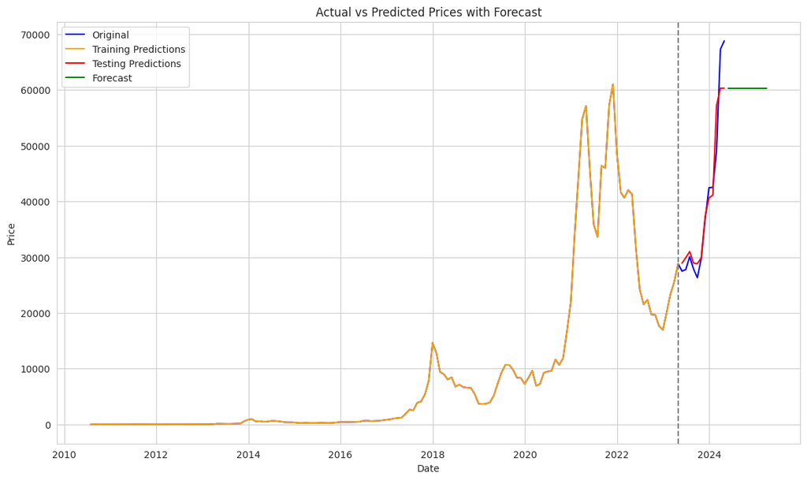

```python
import pandas as pd
import numpy as np
from sklearn.ensemble import RandomForestRegressor, GradientBoostingRegressor
from sklearn.metrics import mean_squared_error, mean_absolute_error
from sklearn.model_selection import GridSearchCV
import matplotlib.pyplot as plt

# Assuming monthly_data2 is already defined and available

# Split the dataset into training and testing sets
training_data = monthly_data2[monthly_data2.index < pd.to_datetime('2023-05-01')]
print("Training data shape:", training_data.shape)

testing_data = monthly_data2[monthly_data2.index >= pd.to_datetime('2023-05-01')]
print("Testing data shape:", testing_data.shape)

# Separate features and target variable
X_train = training_data[['Open', 'High', 'Low', 'Volume', 'Change']]
y_train = training_data['Price']

X_test = testing_data[['Open', 'High', 'Low', 'Volume', 'Change']]
y_test = testing_data['Price']

# Function to perform grid search and return the best model
def perform_grid_search(model, param_grid, X_train, y_train):
    grid_search = GridSearchCV(estimator=model, param_grid=param_grid, cv=3, n_jobs=-1, verbose=2, scoring='neg_mean_squared_error')
    grid_search.fit(X_train, y_train)
    return grid_search.best_estimator_

# Hyperparameter tuning for Random Forest
rf_param_grid = {
    'n_estimators': [100, 200, 300],
    'max_features': ['auto', 'sqrt', 'log2'],
    'max_depth': [10, 20, None],
    'min_samples_split': [2, 5, 10],
    'min_samples_leaf': [1, 2, 4],
    'bootstrap': [True, False]
}
rf_model = perform_grid_search(RandomForestRegressor(random_state=42), rf_param_grid, X_train, y_train)

# Hyperparameter tuning for Gradient Boosting
gb_param_grid = {
    'n_estimators': [100, 200, 300],
    'learning_rate': [0.01, 0.1, 0.3],
    'max_depth': [3, 5, 7],
    'min_samples_split': [2, 5, 10],
    'min_samples_leaf': [1, 2, 4]
}
gb_model = perform_grid_search(GradientBoostingRegressor(random_state=42), gb_param_grid, X_train, y_train)

# Fit the models
rf_model.fit(X_train, y_train)
gb_model.fit(X_train, y_train)

# Make predictions on the training and testing data
rf_train_predictions = rf_model.predict(X_train)
rf_test_predictions = rf_model.predict(X_test)

gb_train_predictions = gb_model.predict(X_train)
gb_test_predictions = gb_model.predict(X_test)

# Combine the predictions for the hybrid model
train_predictions = (rf_train_predictions + gb_train_predictions) / 2
test_predictions = (rf_test_predictions + gb_test_predictions) / 2

# Calculate evaluation metrics for training data
train_mse = mean_squared_error(y_train, train_predictions)
train_rmse = np.sqrt(train_mse)
train_mape = np.mean(np.abs((y_train - train_predictions) / y_train)) * 100

# Calculate evaluation metrics for testing data
test_mse = mean_squared_error(y_test, test_predictions)
test_rmse = np.sqrt(test_mse)
test_mape = np.mean(np.abs((y_test - test_predictions) / y_test)) * 100

# MASE calculation
# Calculate in-sample one-step naive forecast error
naive_forecast_train = training_data['Price'].shift(1)
naive_forecast_error_train = np.abs(training_data['Price'][1:] - naive_forecast_train[1:])
naive_mae_train = np.mean(naive_forecast_error_train)

# Calculate MASE for training data
train_mase = mean_absolute_error(y_train, train_predictions) / naive_mae_train

# Calculate in-sample one-step naive forecast error for testing data
naive_forecast_test = testing_data['Price'].shift(1)
naive_forecast_error_test = np.abs(testing_data['Price'][1:] - naive_forecast_test[1:])
naive_mae_test = np.mean(naive_forecast_error_test)

# Calculate MASE for testing data
test_mase = mean_absolute_error(y_test, test_predictions) / naive_mae_train

print("Evaluation Metrics for Training Data:")
print(f"**Root Mean Squared Error (RMSE):** {train_rmse}")
print(f"**Mean Absolute Percentage Error (MAPE):** {train_mape}")
print(f"**Mean Absolute Scaled Error (MASE):** {train_mase}")

print("\nEvaluation Metrics for Testing Data:")
print(f"**Root Mean Squared Error (RMSE):** {test_rmse}")
print(f"**Mean Absolute Percentage Error (MAPE):** {test_mape}")
print(f"**Mean Absolute Scaled Error (MASE):** {test_mase}")

# Extend the date index for forecast
forecast_dates = pd.date_range(start=testing_data.index[-1], periods=12, freq='M')[1:]

# Extend the features for forecast (you need to adjust this based on your specific forecasting method)
# For simplicity, we'll use the last available data point as a proxy for forecasting future values
last_available_data = testing_data.iloc[-1][['Open', 'High', 'Low', 'Volume', 'Change']].values
extended_features = np.tile(last_available_data, (len(forecast_dates), 1))

# Make predictions for the forecast period
forecast_rf = rf_model.predict(extended_features)
forecast_gb = gb_model.predict(extended_features)

# Combine the forecast predictions
forecast_predictions = (forecast_rf + forecast_gb) / 2

# Plot actual vs predicted prices including forecast
plt.figure(figsize=(14, 8))

# Plot the original prices
plt.plot(monthly_data2.index, monthly_data2['Price'], label='Original', color='blue')

# Plot the training predictions
plt.plot(training_data.index, train_predictions, label='Training Predictions', color='orange')

# Plot the testing predictions
plt.plot(testing_data.index, test_predictions, label='Testing Predictions', color='red')

# Add a vertical line to separate training and testing data
plt.axvline(x=pd.to_datetime('2023-05-01'), color='gray', linestyle='--')

# Plot the forecast
plt.plot(forecast_dates, forecast_predictions, label='Forecast', color='green')

plt.xlabel('Date')
plt.ylabel('Price')
plt.title('Actual vs Predicted Prices with Forecast')
plt.legend()
plt.show()
```

> > Random Forest - CatBoost Hybrid Model

```
Training data shape: (154, 8)
Testing data shape: (12, 8)
Fitting 3 folds for each of 486 candidates, totalling 1458 fits
```

```
Fitting 3 folds for each of 135 candidates, totalling 405 fits
```

```
Evaluation Metrics for Training Data:
**Root Mean Squared Error (RMSE):** 35.79608893420087
**Mean Absolute Percentage Error (MAPE):** 445.8151606722291
**Mean Absolute Scaled Error (MASE):** 0.019799201885881457

Evaluation Metrics for Testing Data:
**Root Mean Squared Error (RMSE):** 4507.932082031228
**Mean Absolute Percentage Error (MAPE):** 5.774366484566997
**Mean Absolute Scaled Error (MASE):** 2.1096357241568624
```

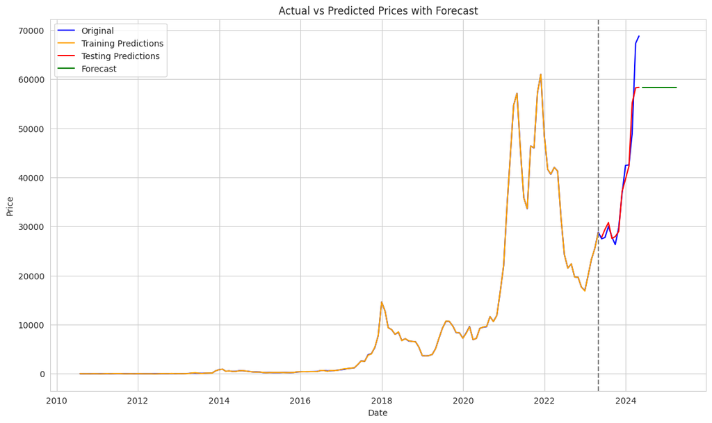

```python
import pandas as pd
import numpy as np
from sklearn.ensemble import RandomForestRegressor
from catboost import CatBoostRegressor
from sklearn.metrics import mean_squared_error, mean_absolute_error
from sklearn.model_selection import GridSearchCV
import matplotlib.pyplot as plt

# Assuming monthly_data2 is already defined and available

# Split the dataset into training and testing sets
training_data = monthly_data2[monthly_data2.index < pd.to_datetime('2023-05-01')]
print("Training data shape:", training_data.shape)

testing_data = monthly_data2[monthly_data2.index >= pd.to_datetime('2023-05-01')]
print("Testing data shape:", testing_data.shape)

# Separate features and target variable
X_train = training_data[['Open', 'High', 'Low', 'Volume', 'Change']]
y_train = training_data['Price']

X_test = testing_data[['Open', 'High', 'Low', 'Volume', 'Change']]
y_test = testing_data['Price']

# Function to perform grid search and return the best model
def perform_grid_search(model, param_grid, X_train, y_train):
    grid_search = GridSearchCV(estimator=model, param_grid=param_grid, cv=3, n_jobs=-1, verbose=2, scoring='neg_mean_squared_error')
    grid_search.fit(X_train, y_train)
    return grid_search.best_estimator_

# Hyperparameter tuning for Random Forest
rf_param_grid = {
    'n_estimators': [100, 200, 300],
    'max_features': ['auto', 'sqrt', 'log2'],
    'max_depth': [10, 20, None],
    'min_samples_split': [2, 5, 10],
    'min_samples_leaf': [1, 2, 4],
    'bootstrap': [True, False]
}
rf_model = perform_grid_search(RandomForestRegressor(random_state=42), rf_param_grid, X_train, y_train)

# Hyperparameter tuning for CatBoost
cb_param_grid = {
    'iterations': [100, 200, 300],
    'depth': [4, 6, 10],
    'learning_rate': [0.01, 0.1, 0.3],
    'l2_leaf_reg': [1, 3, 5, 7, 9]
}
cb_model = perform_grid_search(CatBoostRegressor(random_state=42, verbose=0), cb_param_grid, X_train, y_train)

# Fit the models
rf_model.fit(X_train, y_train)
cb_model.fit(X_train, y_train)

# Make predictions on the training and testing data
rf_train_predictions = rf_model.predict(X_train)
rf_test_predictions = rf_model.predict(X_test)

cb_train_predictions = cb_model.predict(X_train)
cb_test_predictions = cb_model.predict(X_test)

# Combine the predictions for the hybrid model
train_predictions = (rf_train_predictions + cb_train_predictions) / 2
test_predictions = (rf_test_predictions + cb_test_predictions) / 2

# Calculate evaluation metrics for training data
train_mse = mean_squared_error(y_train, train_predictions)
train_rmse = np.sqrt(train_mse)
train_mape = np.mean(np.abs((y_train - train_predictions) / y_train)) * 100

# Calculate evaluation metrics for testing data
test_mse = mean_squared_error(y_test, test_predictions)
test_rmse = np.sqrt(test_mse)
test_mape = np.mean(np.abs((y_test - test_predictions) / y_test)) * 100

# MASE calculation
# Calculate in-sample one-step naive forecast error
naive_forecast_train = training_data['Price'].shift(1)
naive_forecast_error_train = np.abs(training_data['Price'][1:] - naive_forecast_train[1:])
naive_mae_train = np.mean(naive_forecast_error_train)

# Calculate MASE for training data
train_mase = mean_absolute_error(y_train, train_predictions) / naive_mae_train

# Calculate in-sample one-step naive forecast error for testing data
naive_forecast_test = testing_data['Price'].shift(1)
naive_forecast_error_test = np.abs(testing_data['Price'][1:] - naive_forecast_test[1:])
naive_mae_test = np.mean(naive_forecast_error_test)

# Calculate MASE for testing data
test_mase = mean_absolute_error(y_test, test_predictions) / naive_mae_train

print("Evaluation Metrics for Training Data:")
print(f"**Root Mean Squared Error (RMSE):** {train_rmse}")
print(f"**Mean Absolute Percentage Error (MAPE):** {train_mape}")
print(f"**Mean Absolute Scaled Error (MASE):** {train_mase}")

print("\nEvaluation Metrics for Testing Data:")
print(f"**Root Mean Squared Error (RMSE):** {test_rmse}")
print(f"**Mean Absolute Percentage Error (MAPE):** {test_mape}")
print(f"**Mean Absolute Scaled Error (MASE):** {test_mase}")

# Extend the date index for forecast
forecast_dates = pd.date_range(start=testing_data.index[-1], periods=12, freq='M')[1:]

# Extend the features for forecast (you need to adjust this based on your specific forecasting method)
# For simplicity, we'll use the last available data point as a proxy for forecasting future values
last_available_data = testing_data.iloc[-1][['Open', 'High', 'Low', 'Volume', 'Change']].values
extended_features = np.tile(last_available_data, (len(forecast_dates), 1))

# Make predictions for the forecast period
forecast_rf = rf_model.predict(extended_features)
forecast_cb = cb_model.predict(extended_features)

# Combine the forecast predictions
forecast_predictions = (forecast_rf + forecast_cb) / 2

# Plot actual vs predicted prices including forecast
plt.figure(figsize=(14, 8))

# Plot the original prices
plt.plot(monthly_data2.index, monthly_data2['Price'], label='Original', color='blue')

# Plot the training predictions
plt.plot(training_data.index, train_predictions, label='Training Predictions', color='orange')

# Plot the testing predictions
plt.plot(testing_data.index, test_predictions, label='Testing Predictions', color='red')

# Add a vertical line to separate training and testing data
plt.axvline(x=pd.to_datetime('2023-05-01'), color='gray', linestyle='--')

# Plot the forecast
plt.plot(forecast_dates, forecast_predictions, label='Forecast', color='green')

plt.xlabel('Date')
plt.ylabel('Price')
plt.title('Actual vs Predicted Prices with Forecast')
plt.legend()
plt.show()
```

> > Decision Tree - Gradient Boosting Hybrid Model

```
Training data shape: (154, 8)
Testing data shape: (12, 8)
Fitting 3 folds for each of 45 candidates, totalling 135 fits
```

```
Best parameters for Decision Tree found: {'max_depth': None, 'min_samples_leaf': 1, 'min_samples_split': 2}
Fitting 3 folds for each of 243 candidates, totalling 729 fits
Best parameters for Gradient Boosting found: {'learning_rate': 0.1, 'max_depth': 5, 'min_samples_leaf': 1, 'min_samples_split': 5, 'n_estimators': 300}
Evaluation Metrics for Training Data:
**Root Mean Squared Error (RMSE):** 4.4905510159912465e-12
**Mean Absolute Percentage Error (MAPE):** 1.310584576891668e-10
**Mean Absolute Scaled Error (MASE):** 2.622844936658946e-15

Evaluation Metrics for Testing Data:
**Root Mean Squared Error (RMSE):** 4698.873404958538
**Mean Absolute Percentage Error (MAPE):** 9.704624903768675
**Mean Absolute Scaled Error (MASE):** 2.8209708684375854
```

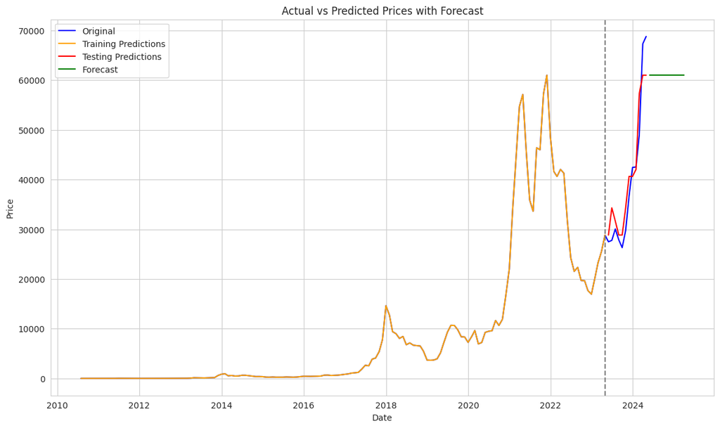

```python
import pandas as pd
import numpy as np
from sklearn.tree import DecisionTreeRegressor
from sklearn.ensemble import GradientBoostingRegressor
from sklearn.linear_model import LinearRegression
from sklearn.metrics import mean_squared_error, mean_absolute_error
from sklearn.model_selection import GridSearchCV
import matplotlib.pyplot as plt

# Assuming monthly_data2 is already defined and available

# Split the dataset into training and testing sets
training_data = monthly_data2[monthly_data2.index < pd.to_datetime('2023-05-01')]
print("Training data shape:", training_data.shape)

testing_data = monthly_data2[monthly_data2.index >= pd.to_datetime('2023-05-01')]
print("Testing data shape:", testing_data.shape)

# Separate features and target variable
X_train = training_data[['Open', 'High', 'Low', 'Volume', 'Change']]
y_train = training_data['Price']

X_test = testing_data[['Open', 'High', 'Low', 'Volume', 'Change']]
y_test = testing_data['Price']

# Hyperparameter tuning for Decision Tree using GridSearchCV
param_grid_dt = {
    'max_depth': [3, 5, 7, 10, None],
    'min_samples_split': [2, 5, 10],
    'min_samples_leaf': [1, 2, 4]
}

dt = DecisionTreeRegressor(random_state=42)
grid_search_dt = GridSearchCV(estimator=dt, param_grid=param_grid_dt, cv=3, n_jobs=-1, verbose=2, scoring='neg_mean_squared_error')
grid_search_dt.fit(X_train, y_train)

# Best parameters from GridSearchCV for Decision Tree
best_params_dt = grid_search_dt.best_params_
print(f"Best parameters for Decision Tree found: {best_params_dt}")

# Create and train the Decision Tree model with the best parameters
dt_model = DecisionTreeRegressor(**best_params_dt, random_state=42)
dt_model.fit(X_train, y_train)

# Hyperparameter tuning for Gradient Boosting using GridSearchCV
param_grid_gb = {
    'n_estimators': [100, 200, 300],
    'max_depth': [3, 4, 5],
    'learning_rate': [0.01, 0.1, 0.2],
    'min_samples_split': [2, 5, 10],
    'min_samples_leaf': [1, 2, 4]
}

gb = GradientBoostingRegressor(random_state=42)
grid_search_gb = GridSearchCV(estimator=gb, param_grid=param_grid_gb, cv=3, n_jobs=-1, verbose=2, scoring='neg_mean_squared_error')
grid_search_gb.fit(X_train, y_train)

# Best parameters from GridSearchCV for Gradient Boosting
best_params_gb = grid_search_gb.best_params_
print(f"Best parameters for Gradient Boosting found: {best_params_gb}")

# Create and train the Gradient Boosting model with the best parameters
gb_model = GradientBoostingRegressor(**best_params_gb, random_state=42)
gb_model.fit(X_train, y_train)

# Use the base models to make predictions
dt_train_pred = dt_model.predict(X_train)
gb_train_pred = gb_model.predict(X_train)

dt_test_pred = dt_model.predict(X_test)
gb_test_pred = gb_model.predict(X_test)

# Combine predictions to train the meta-model
train_meta_features = np.column_stack((dt_train_pred, gb_train_pred))
test_meta_features = np.column_stack((dt_test_pred, gb_test_pred))

# Train the meta-model
meta_model = LinearRegression()
meta_model.fit(train_meta_features, y_train)

# Make predictions with the meta-model
train_predictions = meta_model.predict(train_meta_features)
test_predictions = meta_model.predict(test_meta_features)

# Calculate evaluation metrics for training data
train_mse = mean_squared_error(y_train, train_predictions)
train_rmse = np.sqrt(train_mse)
train_mape = np.mean(np.abs((y_train - train_predictions) / y_train)) * 100

# Calculate evaluation metrics for testing data
test_mse = mean_squared_error(y_test, test_predictions)
test_rmse = np.sqrt(test_mse)
test_mape = np.mean(np.abs((y_test - test_predictions) / y_test)) * 100

# MASE calculation
# Calculate in-sample one-step naive forecast error
naive_forecast_train = training_data['Price'].shift(1)
naive_forecast_error_train = np.abs(training_data['Price'][1:] - naive_forecast_train[1:])
naive_mae_train = np.mean(naive_forecast_error_train)

# Calculate MASE for training data
train_mase = mean_absolute_error(y_train, train_predictions) / naive_mae_train

# Calculate in-sample one-step naive forecast error for testing data
naive_forecast_test = testing_data['Price'].shift(1)
naive_forecast_error_test = np.abs(testing_data['Price'][1:] - naive_forecast_test[1:])
naive_mae_test = np.mean(naive_forecast_error_test)

# Calculate MASE for testing data
test_mase = mean_absolute_error(y_test, test_predictions) / naive_mae_train

print("Evaluation Metrics for Training Data:")
print(f"**Root Mean Squared Error (RMSE):** {train_rmse}")
print(f"**Mean Absolute Percentage Error (MAPE):** {train_mape}")
print(f"**Mean Absolute Scaled Error (MASE):** {train_mase}")

print("\nEvaluation Metrics for Testing Data:")
print(f"**Root Mean Squared Error (RMSE):** {test_rmse}")
print(f"**Mean Absolute Percentage Error (MAPE):** {test_mape}")
print(f"**Mean Absolute Scaled Error (MASE):** {test_mase}")

# Extend the date index for forecast
forecast_dates = pd.date_range(start=testing_data.index[-1], periods=12, freq='M')[1:]

# Extend the features for forecast (you need to adjust this based on your specific forecasting method)
# For simplicity, we'll use the last available data point as a proxy for forecasting future values
last_available_data = testing_data.iloc[-1][['Open', 'High', 'Low', 'Volume', 'Change']].values
extended_features = np.tile(last_available_data, (len(forecast_dates), 1))

# Make predictions for the forecast period using the base models
dt_forecast_pred = dt_model.predict(extended_features)
gb_forecast_pred = gb_model.predict(extended_features)

# Combine predictions for the meta-model
forecast_meta_features = np.column_stack((dt_forecast_pred, gb_forecast_pred))
forecast_predictions = meta_model.predict(forecast_meta_features)

# Plot actual vs predicted prices including forecast
plt.figure(figsize=(14, 8))

# Plot the original prices
plt.plot(monthly_data2.index, monthly_data2['Price'], label='Original', color='blue')

# Plot the training predictions
plt.plot(training_data.index, train_predictions, label='Training Predictions', color='orange')

# Plot the testing predictions
plt.plot(testing_data.index, test_predictions, label='Testing Predictions', color='red')

# Add a vertical line to separate training and testing data
plt.axvline(x=pd.to_datetime('2023-05-01'), color='gray', linestyle='--')

# Plot the forecast
plt.plot(forecast_dates, forecast_predictions, label='Forecast', color='green')

plt.xlabel('Date')
plt.ylabel('Price')
plt.title('Actual vs Predicted Prices with Forecast')
plt.legend()
plt.show()
```

> > Random Forest - CatBoost - Gradient Boosting triple Hybrid Model

```
Training data shape: (154, 8)
Testing data shape: (12, 8)
Fitting 3 folds for each of 486 candidates, totalling 1458 fits
```

```
Fitting 3 folds for each of 135 candidates, totalling 405 fits
Fitting 3 folds for each of 243 candidates, totalling 729 fits
```

```
Evaluation Metrics for Training Data:
**Root Mean Squared Error (RMSE):** 23.86409301184345
**Mean Absolute Percentage Error (MAPE):** 297.2106355288619
**Mean Absolute Scaled Error (MASE):** 0.013199482272852933

Evaluation Metrics for Testing Data:
**Root Mean Squared Error (RMSE):** 4239.845895431008
**Mean Absolute Percentage Error (MAPE):** 5.60118303946038
**Mean Absolute Scaled Error (MASE):** 2.0166829160175554
```

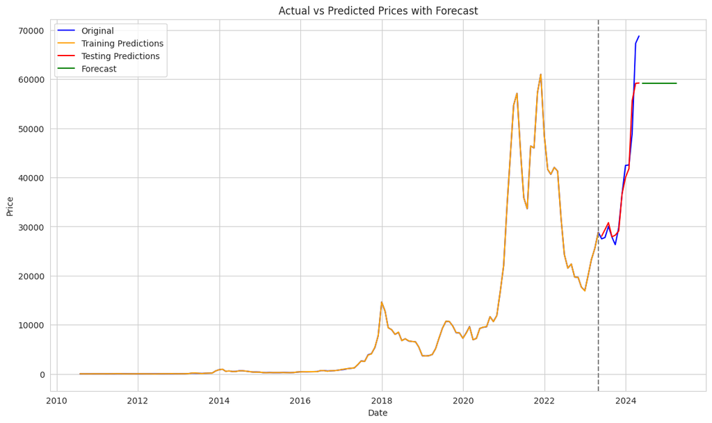

```python
import pandas as pd
import numpy as np
from sklearn.ensemble import RandomForestRegressor, GradientBoostingRegressor
from catboost import CatBoostRegressor
from sklearn.metrics import mean_squared_error, mean_absolute_error
from sklearn.model_selection import GridSearchCV
import matplotlib.pyplot as plt

# Assuming monthly_data2 is already defined and available

# Split the dataset into training and testing sets
training_data = monthly_data2[monthly_data2.index < pd.to_datetime('2023-05-01')]
print("Training data shape:", training_data.shape)

testing_data = monthly_data2[monthly_data2.index >= pd.to_datetime('2023-05-01')]
print("Testing data shape:", testing_data.shape)

# Separate features and target variable
X_train = training_data[['Open', 'High', 'Low', 'Volume', 'Change']]
y_train = training_data['Price']

X_test = testing_data[['Open', 'High', 'Low', 'Volume', 'Change']]
y_test = testing_data['Price']

# Function to perform grid search and return the best model
def perform_grid_search(model, param_grid, X_train, y_train):
    grid_search = GridSearchCV(estimator=model, param_grid=param_grid, cv=3, n_jobs=-1, verbose=2, scoring='neg_mean_squared_error')
    grid_search.fit(X_train, y_train)
    return grid_search.best_estimator_

# Hyperparameter tuning for Random Forest
rf_param_grid = {
    'n_estimators': [100, 200, 300],
    'max_features': ['auto', 'sqrt', 'log2'],
    'max_depth': [10, 20, None],
    'min_samples_split': [2, 5, 10],
    'min_samples_leaf': [1, 2, 4],
    'bootstrap': [True, False]
}
rf_model = perform_grid_search(RandomForestRegressor(random_state=42), rf_param_grid, X_train, y_train)

# Hyperparameter tuning for CatBoost
cb_param_grid = {
    'iterations': [100, 200, 300],
    'depth': [4, 6, 10],
    'learning_rate': [0.01, 0.1, 0.3],
    'l2_leaf_reg': [1, 3, 5, 7, 9]
}
cb_model = perform_grid_search(CatBoostRegressor(random_state=42, verbose=0), cb_param_grid, X_train, y_train)

# Hyperparameter tuning for Gradient Boosting
gb_param_grid = {
    'n_estimators': [100, 200, 300],
    'learning_rate': [0.01, 0.1, 0.3],
    'max_depth': [3, 5, 7],
    'min_samples_split': [2, 5, 10],
    'min_samples_leaf': [1, 2, 4]
}
gb_model = perform_grid_search(GradientBoostingRegressor(random_state=42), gb_param_grid, X_train, y_train)

# Fit the models
rf_model.fit(X_train, y_train)
cb_model.fit(X_train, y_train)
gb_model.fit(X_train, y_train)

# Make predictions on the training and testing data
rf_train_predictions = rf_model.predict(X_train)
rf_test_predictions = rf_model.predict(X_test)

cb_train_predictions = cb_model.predict(X_train)
cb_test_predictions = cb_model.predict(X_test)

gb_train_predictions = gb_model.predict(X_train)
gb_test_predictions = gb_model.predict(X_test)

# Combine the predictions for the hybrid model
train_predictions = (rf_train_predictions + cb_train_predictions + gb_train_predictions) / 3
test_predictions = (rf_test_predictions + cb_test_predictions + gb_test_predictions) / 3

# Calculate evaluation metrics for training data
train_mse = mean_squared_error(y_train, train_predictions)
train_rmse = np.sqrt(train_mse)
train_mape = np.mean(np.abs((y_train - train_predictions) / y_train)) * 100

# Calculate evaluation metrics for testing data
test_mse = mean_squared_error(y_test, test_predictions)
test_rmse = np.sqrt(test_mse)
test_mape = np.mean(np.abs((y_test - test_predictions) / y_test)) * 100

# MASE calculation
# Calculate in-sample one-step naive forecast error
naive_forecast_train = training_data['Price'].shift(1)
naive_forecast_error_train = np.abs(training_data['Price'][1:] - naive_forecast_train[1:])
naive_mae_train = np.mean(naive_forecast_error_train)

# Calculate MASE for training data
train_mase = mean_absolute_error(y_train, train_predictions) / naive_mae_train

# Calculate in-sample one-step naive forecast error for testing data
naive_forecast_test = testing_data['Price'].shift(1)
naive_forecast_error_test = np.abs(testing_data['Price'][1:] - naive_forecast_test[1:])
naive_mae_test = np.mean(naive_forecast_error_test)

# Calculate MASE for testing data
test_mase = mean_absolute_error(y_test, test_predictions) / naive_mae_train

print("Evaluation Metrics for Training Data:")
print(f"**Root Mean Squared Error (RMSE):** {train_rmse}")
print(f"**Mean Absolute Percentage Error (MAPE):** {train_mape}")
print(f"**Mean Absolute Scaled Error (MASE):** {train_mase}")

print("\nEvaluation Metrics for Testing Data:")
print(f"**Root Mean Squared Error (RMSE):** {test_rmse}")
print(f"**Mean Absolute Percentage Error (MAPE):** {test_mape}")
print(f"**Mean Absolute Scaled Error (MASE):** {test_mase}")

# Extend the date index for forecast
forecast_dates = pd.date_range(start=testing_data.index[-1], periods=12, freq='M')[1:]

# Extend the features for forecast (you need to adjust this based on your specific forecasting method)
# For simplicity, we'll use the last available data point as a proxy for forecasting future values
last_available_data = testing_data.iloc[-1][['Open', 'High', 'Low', 'Volume', 'Change']].values
extended_features = np.tile(last_available_data, (len(forecast_dates), 1))

# Make predictions for the forecast period
forecast_rf = rf_model.predict(extended_features)
forecast_cb = cb_model.predict(extended_features)
forecast_gb = gb_model.predict(extended_features)

# Combine the forecast predictions
forecast_predictions = (forecast_rf + forecast_cb + forecast_gb) / 3

# Plot actual vs predicted prices including forecast
plt.figure(figsize=(14, 8))

# Plot the original prices
plt.plot(monthly_data2.index, monthly_data2['Price'], label='Original', color='blue')

# Plot the training predictions
plt.plot(training_data.index, train_predictions, label='Training Predictions', color='orange')

# Plot the testing predictions
plt.plot(testing_data.index, test_predictions, label='Testing Predictions', color='red')

# Add a vertical line to separate training and testing data
plt.axvline(x=pd.to_datetime('2023-05-01'), color='gray', linestyle='--')

# Plot the forecast
plt.plot(forecast_dates, forecast_predictions, label='Forecast', color='green')

plt.xlabel('Date')
plt.ylabel('Price')
plt.title('Actual vs Predicted Prices with Forecast')
plt.legend()
plt.show()
```